# Feature Creation Notebook for Uda ML Nanodegree Capstone Project

The goal of this notebook is to load the datasets that are suggested in the project report, and manipulate them with the goal to produce a bidders_new.csv.

## Exploring the datasets

First will import the libraries involved and load the data. Datasets that are saved in datasets kaggle file and can be found here for quickload are:

- datasets kaggle/human_robot/bids.csv
- datasets kaggle/human_robot/train.csv
- datasets kaggle/human_robot/test.csv
- datasets kaggle/human_robot/sampleSubmission.csv

```python
# Import the necessary libraries
import numpy as np
import pandas as pd
from time import time
import matplotlib.pyplot as plt
from IPython.display import display # Allows the use of display() for DataFrames
#pd.set_option('display.max_rows', None)

# Pretty display for notebooks
%matplotlib inline

# Load the bidders train dataset
data_bidders = pd.read_csv("data/train.csv")

# Load the bids dataset
data_bids = pd.read_csv("data/bids.csv")

# Display the first records the bidders dataset case
print("The first few lines of the bidders dataset are as follows:")
display(data_bidders.head(n=3))

print("\n")

# Display the first records the bids dataset case
print("The first few lines of the bids dataset are as follows:")
display(data_bids.head(n=10))
```

```
The first few lines of the bidders dataset are as follows:
```

|  | bidder_id | payment_account | address | outcome |
| --- | --- | --- | --- | --- |
| 0 | 91a3c57b13234af24875c56fb7e2b2f4rb56a | a3d2de7675556553a5f08e4c88d2c228754av | a3d2de7675556553a5f08e4c88d2c228vt0u4 | 0.0 |
| 1 | 624f258b49e77713fc34034560f93fb3hu3jo | a3d2de7675556553a5f08e4c88d2c228v1sga | ae87054e5a97a8f840a3991d12611fdcrfbq3 | 0.0 |
| 2 | 1c5f4fc669099bfbfac515cd26997bd12ruaj | a3d2de7675556553a5f08e4c88d2c2280cybl | 92520288b50f03907041887884ba49c0cl0pd | 0.0 |

```
The first few lines of the bids dataset are as follows:
```

|  | bid_id | bidder_id | auction | merchandise | device | time | country | ip | url |
| --- | --- | --- | --- | --- | --- | --- | --- | --- | --- |
| 0 | 0 | 8dac2b259fd1c6d1120e519fb1ac14fbqvax8 | ewmzr | jewelry | phone0 | 9759243157894736 | us | 69.166.231.58 | vasstdc27m7nks3 |
| 1 | 1 | 668d393e858e8126275433046bbd35c6tywop | aeqok | furniture | phone1 | 9759243157894736 | in | 50.201.125.84 | jmqlhflrzwuay9c |
| 2 | 2 | aa5f360084278b35d746fa6af3a7a1a5ra3xe | wa00e | home goods | phone2 | 9759243157894736 | py | 112.54.208.157 | vasstdc27m7nks3 |
| 3 | 3 | 3939ac3ef7d472a59a9c5f893dd3e39fh9ofi | jefix | jewelry | phone4 | 9759243157894736 | in | 18.99.175.133 | vasstdc27m7nks3 |
| 4 | 4 | 8393c48eaf4b8fa96886edc7cf27b372dsibi | jefix | jewelry | phone5 | 9759243157894736 | in | 145.138.5.37 | vasstdc27m7nks3 |
| 5 | 5 | e8291466de91b0eb4e1515143c7f74dexy2yr | 3vi4t | mobile | phone7 | 9759243157894736 | ru | 91.107.221.27 | vasstdc27m7nks3 |
| 6 | 6 | eef4c687daf977f64fc1d08675c44444raj3s | kjlzx | mobile | phone2 | 9759243210526315 | th | 152.235.155.159 | j9nl1xmo6fqhcc6 |
| 7 | 7 | ab056855c9ca9d36390feae1fa485883issyg | f5f6k | home goods | phone8 | 9759243210526315 | id | 3.210.112.183 | hnt6hu93a3z1cpc |
| 8 | 8 | d600dc03b11e7d782e1e4dae091b084a1h5ch | h7jjx | home goods | phone9 | 9759243210526315 | th | 103.64.157.225 | vasstdc27m7nks3 |
| 9 | 9 | a58ace8b671a7531c88814bc86b2a34cf0crb | 3zpkj | sporting goods | phone4 | 9759243210526315 | za | 123.28.123.226 | vasstdc27m7nks3 |

### Understanding the datasets

The two datasets above are not really features that can go through a pre-processing step and then thrown straight into a classifier. Instead, from these datasets we first need to extract features. However, prior to that we also need to understand the raw datasets.

#### Exploring bidders dataset

For that, a first step, to understand the bidders dataset will be to:

- Identify how many unique bidders we have,
- how many bidding accounts,
- how many bidding adresses,
- the extend these are mixxed up, meaning that there are accounts or addresses that belong to more than one users.

```python
# Find the number of rows in the dataset
num_rows_bidders = data_bidders.shape[0]

# Find the unique bidders
unique_bidders = data_bidders['bidder_id'].unique()

# Find the number of unique bidder ids in the dataset
num_unique_bidders = len(unique_bidders)

# Find the number of unique payment accounts in the dataset
num_unique_payment_accounts = len(data_bidders['payment_account'].unique())

# Find the number of unique addresses in the dataset
num_unique_addresses = len(data_bidders['address'].unique())

print("The bidders dataset has {} rows.".format(num_rows_bidders))
print("The bidders dataset has {} unique bidders.".format(num_unique_bidders))
print("The bidders dataset has {} unique payment accounts.".format(num_unique_payment_accounts))
print("The bidders dataset has {} unique address.".format(num_unique_addresses))

# Find the number of 1s and 0s (robots/humans) in the dataset
counter = data_bidders['outcome'].value_counts()

print()
print("The dataset consists of {} humans and {} robots, which accounts for {:.2f}% and {:.2f}% \
respectively.".format(counter[0], counter[1], counter[0]/2013*100, counter[1]/2013*100))
```

```
The bidders dataset has 2013 rows.
The bidders dataset has 2013 unique bidders.
The bidders dataset has 2013 unique payment accounts.
The bidders dataset has 2013 unique address.

The dataset consists of 1910 humans and 103 robots, which accounts for 94.88% and 5.12% respectively.
```

**Interpretation:** From the above can be inferred that the bidders dataset do not have any duplicates. I did run this to check since i did not see any explicit mention in the competition page. Also the dataset is heavily skewed towards humans.

#### Exploring bids dataset

Now as far as the auctions dataset goes, the aim is to understand:

- How many bids there are made,
- how many unique bidders participate,
- how many unique auctions there are,
- how many unique merchandise categories are included,
- how many unique devices are used,
- from how many unique countries the bids are,
- how many unique ips the bids are coming from,
- how many unique urls are being used.

```python
# Find the number of rows of the dataset
num_rows_bids = data_bids.shape[0]

# Find the number of unique bids
num_unique_bids = len(data_bids['bid_id'].unique())

# Find how many unique bidders participate
num_unique_bidders = len(data_bids['bidder_id'].unique())

# Find how many unique auctions there are
num_unique_auctions = len(data_bids['auction'].unique())

# Find how many unique merchandise categories are included
num_unique_merchandise_categories = len(data_bids['merchandise'].unique())

# Find how many unique devices are used
num_unique_devices = len(data_bids['device'].unique())

# Find from how many unique countries the bids are coming from
num_unique_countries = len(data_bids['country'].unique())

# Find how many unique ips the bids are coming from
num_unique_ips = len(data_bids['ip'].unique())

# Find how many unique urls are being used
num_unique_urls = len(data_bids['url'].unique())

print("The bids dataset has {} rows.".format(num_rows_bids))
print("The bids dataset has {} unique bids.".format(num_unique_bids))
print("The bids dataset has {} unique bidders.".format(num_unique_bidders))
print("The bids dataset has {} unique auctions.".format(num_unique_auctions))
print("The bids dataset has {} unique merchandise categories."
      .format(num_unique_merchandise_categories))
print("The bids dataset has {} unique devices.".format(num_unique_devices))
print("The bids dataset has {} unique countries.".format(num_unique_countries))
print("The bids dataset has {} unique ips.".format(num_unique_ips))
print("The bids dataset has {} unique urls.".format(num_unique_urls))
```

```
The bids dataset has 7656334 rows.
The bids dataset has 7656334 unique bids.
The bids dataset has 6614 unique bidders.
The bids dataset has 15051 unique auctions.
The bids dataset has 10 unique merchandise categories.
The bids dataset has 7351 unique devices.
The bids dataset has 200 unique countries.
The bids dataset has 2303991 unique ips.
The bids dataset has 1786351 unique urls.
```

**Interpretation:** Many things could be said from this computations. First of all it seems that this file is pretty large with more than 7.5 million rows, but that is expected given that a single user should be able to generate thousands of bids. It also seems that every bid is unique and there are no duplicates.

In addition to that, in the dataset there are 15051 auctions, 7351 unique devices and only 10 categories. This means that there are probably a great deal of observations by every bidder in those categories. Finally, there are around 2.3 million ips and 1.78 million urls that the auctions originate from. This means that one or more bidders might have used plenty of those over time.

#### Plotting the bids dataset

To get a more intuitive understanding of the dataset, in the next cell i am running a check on whether it is sorted in an ascending fashion according to the time column or not, and then plotting the timestamps to check their distribution (if sorted then it should be a straight line).

The time is obfuscated and it seems to be in a unix-like format, meaning that it is an integer starting from a point and incremented since then.

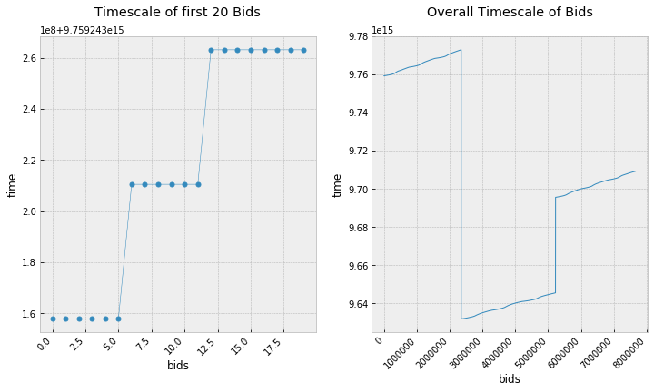

```python
# plotting a figure for all 7m+ ids including the ones that do not exist
import matplotlib as mpl

# style
plt.style.use('bmh')

def plot_the_timeseries(ts, bb=20):

    # init the figure and the axes object
    fig, (ax1, ax2) = plt.subplots(1, 2)
    fig.set_tight_layout(False)
    #print(fig.get_figwidth())
    #print(fig.get_figheight())

    # adjust the size of the figure
    fig.set_figwidth(12)
    fig.set_figheight(6)
    # plot
    ax1.plot(ts[:bb], '-o', linewidth=0.5, markersize=5)#markeredgewidth=0.1,
    ax2.plot(ts, '-', linewidth=1, markersize=1)#markeredgewidth=0.1,
    # set text axes 1
    ax1.set_title('Timescale of first {} Bids\n'.format(bb))
    ax1.set_xlabel('bids')
    ax1.set_ylabel('time')
    # set text axes 2
    ax2.set_title('Overall Timescale of Bids\n')
    ax2.set_xlabel('bids')
    ax2.set_ylabel('time')
    # get the labels to rotate them
    labels1 = ax1.get_xticklabels()
    labels2 = ax2.get_xticklabels()
    # rotate
    plt.setp(labels1, rotation=45, horizontalalignment='right')
    plt.setp(labels2, rotation=45, horizontalalignment='right')
    # show
    plt.show()

# plot the the timeseries
plot_the_timeseries(data_bids['time'])
```

**Interpretation:** From the second plot, the Overall Timescale of Bids it is evident that there are 3 trends that are seemingly monotonic as their value increases or remains stable. By looking closer at the first 20 bids, it seems that the way they increment is by batches (probably due to the refresh rate of the auctions website, that might be sampling at a given frequency). The latter means that in a given timestamp there might be several bids.

#### Shortening the bids dataset

For the reason explained earlier, that is that the bids dataset includes around 7.5m values, i think it might be useful to shorten the dataset and keep only the bid rows that have a valid bidder id (which are the ids that appear in the bidders dataset for which there are labels), and then re-run and compare the same descriptive code to see how many are gone etc.

```python
#Shorten the bids dataset
data_bids = data_bids[data_bids['bidder_id'].isin(unique_bidders)]

# Find the number of rows of the dataset
num_rows_bids_shortened_1 = data_bids.shape[0]

# Find the number of unique bids
num_unique_bids_shortened_1 = len(data_bids['bid_id'].unique())

# Find how many unique bidders participate
num_unique_bidders_shortened_1 = len(data_bids['bidder_id'].unique())

# Find how many unique auctions there are
num_unique_auctions_shortened_1 = len(data_bids['auction'].unique())

# Find how many unique merchandise categories are included
num_unique_merchandise_categories_shortened_1 = len(data_bids['merchandise'].unique())

# Find how many unique devices are used
num_unique_devices_shortened_1 = len(data_bids['device'].unique())

# Find from how many unique countries the bids are coming from
num_unique_countries_shortened_1 = len(data_bids['country'].unique())

# Find how many unique ips the bids are coming from
num_unique_ips_shortened_1 = len(data_bids['ip'].unique())

# Find how many unique urls are being used
num_unique_urls_shortened_1 = len(data_bids['url'].unique())

print("The bids dataset has {} rows.".format(num_rows_bids_shortened_1))
print("The bids dataset has {} unique bids.".format(num_unique_bids_shortened_1))
print("The bids dataset has {} unique bidders.".format(num_unique_bidders_shortened_1))
print("The bids dataset has {} unique auctions.".format(num_unique_auctions_shortened_1))
print("The bids dataset has {} unique merchandise categories."
      .format(num_unique_merchandise_categories_shortened_1))
print("The bids dataset has {} unique devices.".format(num_unique_devices_shortened_1))
print("The bids dataset has {} unique countries.".format(num_unique_countries_shortened_1))
print("The bids dataset has {} unique ips.".format(num_unique_ips_shortened_1))
print("The bids dataset has {} unique urls.".format(num_unique_urls_shortened_1))
```

```
The bids dataset has 3071224 rows.
The bids dataset has 3071224 unique bids.
The bids dataset has 1984 unique bidders.
The bids dataset has 12740 unique auctions.
The bids dataset has 10 unique merchandise categories.
The bids dataset has 5729 unique devices.
The bids dataset has 199 unique countries.
The bids dataset has 1030950 unique ips.
The bids dataset has 663873 unique urls.
```

One idea could potentially be to drop those cases along with the cases where there are not enough data to make an inference, but that is probably done after building the classifier, by adjusting the threshold of deciding who is robot or not considering also the number of bids he/she has made.

#### Plotting the shortened bids dataset

Besides seeing the changes in the absolute numbers, it might be informative to see how shortening affected the dataset in terms of the timeseries plot. That could potentially show big gaps in the data after shortening (for example it might be that the test data had included one of the trends and not just bids from all across the timeseries.

In order to do that though, first we need to make a helper pandas series. That series will be at length equal to the initial dataframe. It will retain the timeseries indices of the shortened dataframe, and the remaining ones will be NaN.

```
The first 20 values of the helper timeseries are:
```

```
0              NaN
1     9.759243e+15
2              NaN
3              NaN
4              NaN
5     9.759243e+15
6              NaN
7              NaN
8              NaN
9     9.759243e+15
10    9.759243e+15
11             NaN
12             NaN
13    9.759243e+15
14             NaN
15    9.759243e+15
16             NaN
17             NaN
18             NaN
19    9.759243e+15
Name: time, dtype: float64
```

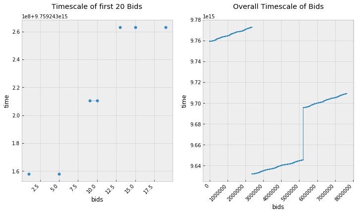

```python
# initialize the new series
helper_timeseries = pd.Series(data_bids['time'], index=range(num_rows_bids))

# show a glimpse of the new series
print("The first 20 values of the helper timeseries are:")
display(helper_timeseries[:20])
print("\n")

# plot the the shortened timeseries
plot_the_timeseries(helper_timeseries)
```

**Interpretation:** The visualization shows a similar general trend at the second plot but that is not the case in the first plot where a lot of values are missing. We can verify what se see at the first 20 values of the helper timeseries, as there are only two adjucent-connected values in indices 9 and 10. The second plot is simply to broad to show the unconnectedness, however compared to the first one there is some mild rigidness and uncontinuity due to the fact that there are missing values all accross the timeseries.

#### Monotony check

A next step after shortening is to bring the dataset into a useful monotonic order. But just before stepping into this it is worth running a check as to what extend is the timeseries in ascending order. From the plot earlier, we can see that there is a point at around index 2.3m where there is a drop in value. There the monotony breaks it is obvious. But there might be subtleties that are not becoming visible by the overall graph. In order to do that i will run a check in the next cell* **.

* *I did run the check with a lot of trial and error and came up with the one index of the one visible monotony break. There was no need for a more complex function since it was easy to find it that way and that in the end there were no other subtle breaks.*

** The index is much smaller than around the 2.3m mark because the data frame is shortened.

```python
mono_break_idx = 917771

# check that the dataset is sorted in regards to time
mono_check_bids_first_half = data_bids.iloc[:mono_break_idx]['time'].is_monotonic

if mono_check_bids_first_half:
    print("The first half of the data is in order until index {}"
          .format(mono_break_idx))

# check that the dataset is sorted in regards to time
mono_check_bids_second_half = data_bids.iloc[mono_break_idx:]['time'].is_monotonic

if mono_check_bids_second_half:
    print("The second half of the data is in order, starting from index {}."
          .format(mono_break_idx))

print()
print("Here is a view of the table around the row in index {} where monotony breaks:"
      .format(data_bids.iloc[mono_break_idx].name))

# display the area of the dataset that is not in order (found this by some trial and error)
display(data_bids[mono_break_idx-3:mono_break_idx+3])
```

```
The first half of the data is in order until index 917771
The second half of the data is in order, starting from index 917771.

Here is a view of the table around the row in index 2351187 where monotony breaks:
```

|  | bid_id | bidder_id | auction | merchandise | device | time | country | ip | url |
| --- | --- | --- | --- | --- | --- | --- | --- | --- | --- |
| 2351179 | 2351179 | 19b39b852ed4abf1ba5b095829e25b946aed1 | l98lx | sporting goods | phone46 | 9772885210526315 | au | 8.116.0.253 | gzt8jm8b856j2o3 |
| 2351180 | 2351180 | 76f17ce227e593aeff456fed46e36c83a3j72 | 7l830 | mobile | phone179 | 9772885210526315 | in | 64.78.53.112 | rpt2umq2eorj5nb |
| 2351181 | 2351181 | 0d1815382b08885d76c671ab600133adeyp5e | hsitf | jewelry | phone4 | 9772885210526315 | in | 163.12.180.50 | vasstdc27m7nks3 |
| 2351187 | 2351187 | 76218e14c379c12d599dae9e1c00b61a3i5b2 | 6hpvy | sporting goods | phone1161 | 9631916842105263 | cz | 121.169.96.51 | f33fl83l4vrg6is |
| 2351188 | 2351188 | f5b2bbad20d1d7ded3ed960393bec0f40u6hn | 64uay | sporting goods | phone0 | 9631916842105263 | ke | 17.120.130.121 | vasstdc27m7nks3 |
| 2351190 | 2351190 | f5b2bbad20d1d7ded3ed960393bec0f40u6hn | fagyq | sporting goods | phone1 | 9631916842105263 | in | 161.192.187.34 | 3skc4v2r07bneta |

**Interpretation:** The dataframe appears to be sorted monotonicaly according the 'time' column with one break that happens after around one third of the values. It seems that this series that is at the front should be at the end given that it starts higher than the other two.

#### Transforming the bids dataset

According to how the dataset looks like so far, there are probably two more things that would be useful to be done to it; these are:

1. To sort it properly according to the time column (so that time is always ascending),
2. to normalize the time so that it starts from 0 and*,
3. to readjust the index so that there are no "holes" to it like we see in the helper series where many indices have Nan when plotted.

As far as the first point is concerned, it is needed for when we create tables for features later on which will be ordered from the get go and they will not need to be sorted again. Also, by normalizing it is easier to understand the timeseries (how it increments etc.) since the numbers will be shorter - this ordering doesn't make sense anyway as it is since it is transformed to protect privacy. Finally by normalizing plotting is being made easier and also understanding the data easier when looking at a clipped table. The original id will be kept in bid_id but it is not needed anyway.

* *In order to do that i will find the lowest value and subtract it from all values so that the lowest value (that should be at index 0), is itself 0.*

```
Here are the 20 first values of the dataframe after sorting it according to time column.
```

|  | bid_id | bidder_id | auction | merchandise | device | time | country | ip | url |
| --- | --- | --- | --- | --- | --- | --- | --- | --- | --- |
| 2351187 | 2351187 | 76218e14c379c12d599dae9e1c00b61a3i5b2 | 6hpvy | sporting goods | phone1161 | 9631916842105263 | cz | 121.169.96.51 | f33fl83l4vrg6is |
| 2351188 | 2351188 | f5b2bbad20d1d7ded3ed960393bec0f40u6hn | 64uay | sporting goods | phone0 | 9631916842105263 | ke | 17.120.130.121 | vasstdc27m7nks3 |
| 2351190 | 2351190 | f5b2bbad20d1d7ded3ed960393bec0f40u6hn | fagyq | sporting goods | phone1 | 9631916842105263 | in | 161.192.187.34 | 3skc4v2r07bneta |
| 2351192 | 2351192 | 197e90906939267ace2422e78e8e83889znqp | gst86 | home goods | phone348 | 9631916842105263 | ma | 154.151.182.60 | vasstdc27m7nks3 |
| 2351193 | 2351193 | d65efaa8129a85f85bf909e5abde8c3628gfv | i01xm | jewelry | phone13 | 9631916842105263 | sg | 113.217.213.15 | eovsi6u99d9b72w |
| 2351194 | 2351194 | 3d7cff3dedd8a8e02dbc551c6a61da3bibbvh | 5mqsv | home goods | phone4 | 9631916842105263 | vn | 235.207.16.31 | vasstdc27m7nks3 |
| 2351200 | 2351200 | 6e178db6d17d21aa88aaca5bf15c2761lc500 | jqx39 | jewelry | phone99 | 9631916842105263 | sa | 174.12.78.255 | omwhmwzvrn6ycq6 |
| 2351203 | 2351203 | 3a5420301c0dacbc5675f6f09aac0143tuodl | jqx39 | jewelry | phone25 | 9631916894736842 | vn | 48.186.219.240 | a9oo5hbdagf0r9c |
| 2351204 | 2351204 | f5b2bbad20d1d7ded3ed960393bec0f40u6hn | 4gor9 | sporting goods | phone76 | 9631916894736842 | vn | 14.194.184.32 | vasstdc27m7nks3 |
| 2351207 | 2351207 | f5b2bbad20d1d7ded3ed960393bec0f40u6hn | wex35 | sporting goods | phone47 | 9631916894736842 | vn | 194.118.13.99 | qs3gam468xmaicl |
| 2351208 | 2351208 | f5b2bbad20d1d7ded3ed960393bec0f40u6hn | 5umtc | sporting goods | phone246 | 9631916894736842 | ng | 236.63.15.129 | hzf1w0ng0m908gu |
| 2351211 | 2351211 | 9655ccc7c0c193f1549475f02c54dce45kjw7 | jqx39 | sporting goods | phone290 | 9631916894736842 | de | 13.173.247.96 | vasstdc27m7nks3 |
| 2351212 | 2351212 | 7264bde42ef4fe3fa19cc7c6d64696cf7pqtd | jqx39 | jewelry | phone648 | 9631916947368421 | in | 244.27.103.108 | bm707sbje2nxucf |
| 2351215 | 2351215 | 15972a431aed117840dfce5556242366c3fwq | qos1f | books and music | phone46 | 9631916947368421 | au | 4.26.11.27 | 9glvwsklfgh260d |
| 2351220 | 2351220 | c2294751630e49a4e594dfd89383b271qzp0m | ewn4v | mobile | phone35 | 9631916947368421 | my | 50.199.12.3 | 66sbokg6z40xxr6 |
| 2351222 | 2351222 | f5b2bbad20d1d7ded3ed960393bec0f40u6hn | uvnl7 | sporting goods | phone72 | 9631916947368421 | ng | 203.173.117.223 | q0skvht51258k93 |
| 2351223 | 2351223 | f5b2bbad20d1d7ded3ed960393bec0f40u6hn | xogrk | sporting goods | phone35 | 9631916947368421 | ng | 247.111.182.120 | 2nsgfbtin9ndkll |
| 2351224 | 2351224 | 4af5e2532224f9f7d1d039704573d9205jbkv | jqx39 | sporting goods | phone52 | 9631916947368421 | sa | 202.163.102.223 | n01ruj9s6henwwn |
| 2351225 | 2351225 | 9655ccc7c0c193f1549475f02c54dce45kjw7 | jqx39 | sporting goods | phone204 | 9631916947368421 | de | 193.200.204.116 | vasstdc27m7nks3 |
| 2351229 | 2351229 | f5b2bbad20d1d7ded3ed960393bec0f40u6hn | 62d9x | sporting goods | phone49 | 9631917000000000 | in | 1.158.230.21 | fezw942t15um898 |

```
Here are the 20 first values of the dataframe after normalizing the timer.
```

|  | bid_id | bidder_id | auction | merchandise | device | time | country | ip | url |
| --- | --- | --- | --- | --- | --- | --- | --- | --- | --- |
| 2351187 | 2351187 | 76218e14c379c12d599dae9e1c00b61a3i5b2 | 6hpvy | sporting goods | phone1161 | 0 | cz | 121.169.96.51 | f33fl83l4vrg6is |
| 2351188 | 2351188 | f5b2bbad20d1d7ded3ed960393bec0f40u6hn | 64uay | sporting goods | phone0 | 0 | ke | 17.120.130.121 | vasstdc27m7nks3 |
| 2351190 | 2351190 | f5b2bbad20d1d7ded3ed960393bec0f40u6hn | fagyq | sporting goods | phone1 | 0 | in | 161.192.187.34 | 3skc4v2r07bneta |
| 2351192 | 2351192 | 197e90906939267ace2422e78e8e83889znqp | gst86 | home goods | phone348 | 0 | ma | 154.151.182.60 | vasstdc27m7nks3 |
| 2351193 | 2351193 | d65efaa8129a85f85bf909e5abde8c3628gfv | i01xm | jewelry | phone13 | 0 | sg | 113.217.213.15 | eovsi6u99d9b72w |
| 2351194 | 2351194 | 3d7cff3dedd8a8e02dbc551c6a61da3bibbvh | 5mqsv | home goods | phone4 | 0 | vn | 235.207.16.31 | vasstdc27m7nks3 |
| 2351200 | 2351200 | 6e178db6d17d21aa88aaca5bf15c2761lc500 | jqx39 | jewelry | phone99 | 0 | sa | 174.12.78.255 | omwhmwzvrn6ycq6 |
| 2351203 | 2351203 | 3a5420301c0dacbc5675f6f09aac0143tuodl | jqx39 | jewelry | phone25 | 52631579 | vn | 48.186.219.240 | a9oo5hbdagf0r9c |
| 2351204 | 2351204 | f5b2bbad20d1d7ded3ed960393bec0f40u6hn | 4gor9 | sporting goods | phone76 | 52631579 | vn | 14.194.184.32 | vasstdc27m7nks3 |
| 2351207 | 2351207 | f5b2bbad20d1d7ded3ed960393bec0f40u6hn | wex35 | sporting goods | phone47 | 52631579 | vn | 194.118.13.99 | qs3gam468xmaicl |
| 2351208 | 2351208 | f5b2bbad20d1d7ded3ed960393bec0f40u6hn | 5umtc | sporting goods | phone246 | 52631579 | ng | 236.63.15.129 | hzf1w0ng0m908gu |
| 2351211 | 2351211 | 9655ccc7c0c193f1549475f02c54dce45kjw7 | jqx39 | sporting goods | phone290 | 52631579 | de | 13.173.247.96 | vasstdc27m7nks3 |
| 2351212 | 2351212 | 7264bde42ef4fe3fa19cc7c6d64696cf7pqtd | jqx39 | jewelry | phone648 | 105263158 | in | 244.27.103.108 | bm707sbje2nxucf |
| 2351215 | 2351215 | 15972a431aed117840dfce5556242366c3fwq | qos1f | books and music | phone46 | 105263158 | au | 4.26.11.27 | 9glvwsklfgh260d |
| 2351220 | 2351220 | c2294751630e49a4e594dfd89383b271qzp0m | ewn4v | mobile | phone35 | 105263158 | my | 50.199.12.3 | 66sbokg6z40xxr6 |
| 2351222 | 2351222 | f5b2bbad20d1d7ded3ed960393bec0f40u6hn | uvnl7 | sporting goods | phone72 | 105263158 | ng | 203.173.117.223 | q0skvht51258k93 |
| 2351223 | 2351223 | f5b2bbad20d1d7ded3ed960393bec0f40u6hn | xogrk | sporting goods | phone35 | 105263158 | ng | 247.111.182.120 | 2nsgfbtin9ndkll |
| 2351224 | 2351224 | 4af5e2532224f9f7d1d039704573d9205jbkv | jqx39 | sporting goods | phone52 | 105263158 | sa | 202.163.102.223 | n01ruj9s6henwwn |
| 2351225 | 2351225 | 9655ccc7c0c193f1549475f02c54dce45kjw7 | jqx39 | sporting goods | phone204 | 105263158 | de | 193.200.204.116 | vasstdc27m7nks3 |
| 2351229 | 2351229 | f5b2bbad20d1d7ded3ed960393bec0f40u6hn | 62d9x | sporting goods | phone49 | 157894737 | in | 1.158.230.21 | fezw942t15um898 |

```
Here are the 20 first values of the dataframe after setting the new index.
```

|  | bid_id | bidder_id | auction | merchandise | device | time | country | ip | url |
| --- | --- | --- | --- | --- | --- | --- | --- | --- | --- |
| 0 | 2351187 | 76218e14c379c12d599dae9e1c00b61a3i5b2 | 6hpvy | sporting goods | phone1161 | 0 | cz | 121.169.96.51 | f33fl83l4vrg6is |
| 1 | 2351188 | f5b2bbad20d1d7ded3ed960393bec0f40u6hn | 64uay | sporting goods | phone0 | 0 | ke | 17.120.130.121 | vasstdc27m7nks3 |
| 2 | 2351190 | f5b2bbad20d1d7ded3ed960393bec0f40u6hn | fagyq | sporting goods | phone1 | 0 | in | 161.192.187.34 | 3skc4v2r07bneta |
| 3 | 2351192 | 197e90906939267ace2422e78e8e83889znqp | gst86 | home goods | phone348 | 0 | ma | 154.151.182.60 | vasstdc27m7nks3 |
| 4 | 2351193 | d65efaa8129a85f85bf909e5abde8c3628gfv | i01xm | jewelry | phone13 | 0 | sg | 113.217.213.15 | eovsi6u99d9b72w |
| 5 | 2351194 | 3d7cff3dedd8a8e02dbc551c6a61da3bibbvh | 5mqsv | home goods | phone4 | 0 | vn | 235.207.16.31 | vasstdc27m7nks3 |
| 6 | 2351200 | 6e178db6d17d21aa88aaca5bf15c2761lc500 | jqx39 | jewelry | phone99 | 0 | sa | 174.12.78.255 | omwhmwzvrn6ycq6 |
| 7 | 2351203 | 3a5420301c0dacbc5675f6f09aac0143tuodl | jqx39 | jewelry | phone25 | 52631579 | vn | 48.186.219.240 | a9oo5hbdagf0r9c |
| 8 | 2351204 | f5b2bbad20d1d7ded3ed960393bec0f40u6hn | 4gor9 | sporting goods | phone76 | 52631579 | vn | 14.194.184.32 | vasstdc27m7nks3 |
| 9 | 2351207 | f5b2bbad20d1d7ded3ed960393bec0f40u6hn | wex35 | sporting goods | phone47 | 52631579 | vn | 194.118.13.99 | qs3gam468xmaicl |
| 10 | 2351208 | f5b2bbad20d1d7ded3ed960393bec0f40u6hn | 5umtc | sporting goods | phone246 | 52631579 | ng | 236.63.15.129 | hzf1w0ng0m908gu |
| 11 | 2351211 | 9655ccc7c0c193f1549475f02c54dce45kjw7 | jqx39 | sporting goods | phone290 | 52631579 | de | 13.173.247.96 | vasstdc27m7nks3 |
| 12 | 2351212 | 7264bde42ef4fe3fa19cc7c6d64696cf7pqtd | jqx39 | jewelry | phone648 | 105263158 | in | 244.27.103.108 | bm707sbje2nxucf |
| 13 | 2351215 | 15972a431aed117840dfce5556242366c3fwq | qos1f | books and music | phone46 | 105263158 | au | 4.26.11.27 | 9glvwsklfgh260d |
| 14 | 2351220 | c2294751630e49a4e594dfd89383b271qzp0m | ewn4v | mobile | phone35 | 105263158 | my | 50.199.12.3 | 66sbokg6z40xxr6 |
| 15 | 2351222 | f5b2bbad20d1d7ded3ed960393bec0f40u6hn | uvnl7 | sporting goods | phone72 | 105263158 | ng | 203.173.117.223 | q0skvht51258k93 |
| 16 | 2351223 | f5b2bbad20d1d7ded3ed960393bec0f40u6hn | xogrk | sporting goods | phone35 | 105263158 | ng | 247.111.182.120 | 2nsgfbtin9ndkll |
| 17 | 2351224 | 4af5e2532224f9f7d1d039704573d9205jbkv | jqx39 | sporting goods | phone52 | 105263158 | sa | 202.163.102.223 | n01ruj9s6henwwn |
| 18 | 2351225 | 9655ccc7c0c193f1549475f02c54dce45kjw7 | jqx39 | sporting goods | phone204 | 105263158 | de | 193.200.204.116 | vasstdc27m7nks3 |
| 19 | 2351229 | f5b2bbad20d1d7ded3ed960393bec0f40u6hn | 62d9x | sporting goods | phone49 | 157894737 | in | 1.158.230.21 | fezw942t15um898 |

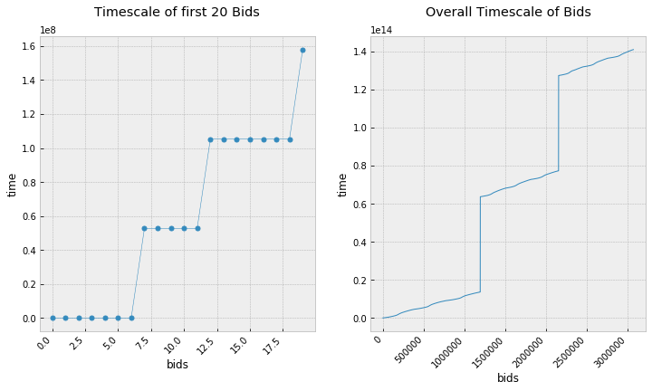

```python
# sort the dataframe according to 'time' and 'bid_id' column (primarily time)
data_bids.sort_values(by=['time', 'bid_id'], inplace=True)

print_values = 20

# test
print('Here are the {} first values of the dataframe after sorting it according to time column.'
      .format(print_values))
display(data_bids.head(print_values))
print('\n')

# find the oldest time value
oldest_time_value = data_bids['time'].iloc[0]

# reduce all values in the time column by the amount of the smallest time value
data_bids['time'] = data_bids['time'].subtract(oldest_time_value)

# test
print('Here are the {} first values of the dataframe after normalizing the timer.'
      .format(print_values))
display(data_bids.head(print_values))
print('\n')

# set the index to properly reflect the iloc
data_bids.set_index([list(range(data_bids.shape[0]))], inplace=True)

# test
print('Here are the {} first values of the dataframe after setting the new index.'
      .format(print_values))
display(data_bids.head(print_values))
print('\n')

# plot the timeseries of the new dataframe
plot_the_timeseries(data_bids['time'])
```

**Interpretation:** It is obvious that a cleaner and shorter dataframe appears to be in the plot. The part of the plot that was being plotted in the beginning of 'bids' axis is now last, the time values start from 0, and the population is shortened at around 3.1m with no missing values.

The three trends observed earlier are still here, and it seems that there are two periods where auction activity must be stopped organically (from the platform or something like that). Maybe that was for maintenance maybe there were no auctions because there were just noone auctioning or the platform paused them for some reason; in any case that is not specified by the authority issuing the data.

#### Shortening the bidders and bids dataset by dropping not needed columns

In addition to these processes and the rows shortening on the bids dataset for this project the bid_id columns is not useful so i will drop it here. This might be a foreign key to allow indexing on other tables but for this project it is not needed.

The bidders dataset also seems to have some useless columns. As seen earlier, all e-mail addresses and payment account are unique, and they are also obfuscated to protect privacy. They do not seem to offer anything to a learner. I will also drop them here.

```python
# drop the columns
data_bids.drop(columns=['bid_id'], inplace=True)

# drop the columns
data_bidders.drop(columns=['address', 'payment_account'], inplace=True)

# confirm it happened
display(data_bids.head(3))

# confirm it happened
display(data_bidders.head(3))
```

|  | bidder_id | auction | merchandise | device | time | country | ip | url |
| --- | --- | --- | --- | --- | --- | --- | --- | --- |
| 0 | 76218e14c379c12d599dae9e1c00b61a3i5b2 | 6hpvy | sporting goods | phone1161 | 0 | cz | 121.169.96.51 | f33fl83l4vrg6is |
| 1 | f5b2bbad20d1d7ded3ed960393bec0f40u6hn | 64uay | sporting goods | phone0 | 0 | ke | 17.120.130.121 | vasstdc27m7nks3 |
| 2 | f5b2bbad20d1d7ded3ed960393bec0f40u6hn | fagyq | sporting goods | phone1 | 0 | in | 161.192.187.34 | 3skc4v2r07bneta |

|  | bidder_id | outcome |
| --- | --- | --- |
| 0 | 91a3c57b13234af24875c56fb7e2b2f4rb56a | 0.0 |
| 1 | 624f258b49e77713fc34034560f93fb3hu3jo | 0.0 |
| 2 | 1c5f4fc669099bfbfac515cd26997bd12ruaj | 0.0 |

#### Shortening the bidders and bids dataset further

Besides dropping the bid ids for bids set, and the addresses and payment accounts for the bidders set, another idea would be to drop the bidders (and their corresponding bids) for whom we have very little information. For example if there is a bidder for whom we have 0 or only 2-3 bids, that is very little information to make an inference, except if there is a super-human unique characteristic, like betting extremely fast, which is a good enough predictor.

For that reason i think it would make sense if i alter the problem a little bit and try to build a classifier only for when there is already some basic history.

*In addition to that i will also run a check for whether the new tables that are being made with such a function are monotonic, because i will construct them in such a way later on and i'd rather not lose time on that.*

```python
number_of_bids = 20

np.set_printoptions(threshold=4)

# maybe make dict comprehension
d = {k: v for (k, v) in zip(np.arange(number_of_bids),
                            [np.array([]) for x in np.arange(number_of_bids)])}

# find users names with 0 bids that will not appear in groupby
d[0] = data_bidders['bidder_id'][~data_bidders['bidder_id'].isin(data_bids['bidder_id'])].values

for bidder_id, group in data_bids.groupby('bidder_id'):

    if group.shape[0]<number_of_bids:
        idx = group.shape[0]
        d[idx] = np.append(d[idx], bidder_id)

    # check if the new dataframe is sorted by the columns and throw a ValueError if not
    mono_check_bidders = group['time'].is_monotonic

    if not mono_check_bidders:
        print("Warning! Bidder id '{}' does not have sorted bidder table! Sorting is needed.."
              .format(bidder_id))

for k, v in d.items():
    print("The {} bidders with {} entries are:{}\n".format(len(v), k, v))

# Find the unique bidders
print("There are {} bidders with {} or more bids."
      .format(np.sum([len(x) for x in d.values()]), number_of_bids))
```

```
The 29 bidders with 0 entries are:['5f50c6187a179e2ee7ba2fbcfc845c7a1smgr'
 '02bde521e763e4f4e590e8368149e04a96il9'
 'dd661e2d6e79a5b3e66c82373d50f3ee86k85' ...
 '40fafe756c4695b32df7d19d4c710dabvzr79'
 '583ce05b5add00d9e7e5dcefb3c436f26d7c2'
 '4fcdd880c4e1a1767c4d26f74bb3466f11osj']

The 302 bidders with 1 entries are:['001068c415025a009fee375a12cff4fcnht8y'
 '0030a2dd87ad2733e0873062e4f83954mkj86'
 '01f498a0992d280de63ec346692efb2blckg2' ...
 'fc48aad7a51d965595b59550e08b94c670k7w'
 'fe4906ac4c8e2db5ed5a71e8a9d10080u6g7o'
 'fff2c070d8200e0a09150bd81452ce29ngcnv']

The 146 bidders with 2 entries are:['01c1c7be49cd6cfbb9075925a05c9899p41va'
 '02cfc97e8fded77671e71e1951723d5fwz6a4'
 '036a4050a5dd65e70f0f613ec2e38a74re026' ...
 'fae963b2adbefc663692d7feddb50d5dxz1hn'
 'fb5a19240e36ae12aaccc1e9d9231144l32hv'
 'fdf0eb91ae1ecea1f6902676f47c32c454yzr']

The 90 bidders with 3 entries are:['00cc97158e6f4cb8eac3c0075918b7ffi5k8o'
 '01eb9dcbd0b3e79d94020d13d83a993ec9d2a'
 '024cf43497fd7381df6254888670f84bwbbam' ...
 'fdad47d27b793b74470086c35333d4fepycsl'
 'ff566c87f2babf3dcd67be286e1c6666cxzh1'
 'ffaf0a972a6dcb3910fd6b16045781e2ava5y']

The 80 bidders with 4 entries are:['026819504b59bc4eefb9963d5fe4271aql15u'
 '042780ee9a3730703e35340c575c3cbb7zjwk'
 '04636b6c61c80f5325efe61183e8edb01ko20' ...
 'fec57d2db5692eb144a71aaa35a11b58delkw'
 'ff12cd48c7de8ffb8b2099f262ce03980dqqz'
 'ff3ae9450581aa3de5d2326f70e39d20w8fbl']

The 51 bidders with 5 entries are:['02030ec48b7179a7fd9950fdf546e3feekkye'
 '10383b390780e7b4b03dc32c94b4973f66wou'
 '120beb4523541f769a2b658cbc41dd57w7im7' ...
 'e959a3ae64e28a7d3b37934c0d826867o3sp6'
 'f90f13ddfc0f98cbe3c2346a2e30093cq6zo0'
```

[output cut: 86 more lines]

```
The 10 bidders with 18 entries are:['0141844fc725a85e38e12cc02fcdbbe8ofqxv'
 '07012e0507b4281d430b93ddcd96cae66und7'
 '16065749457a14b26998fefca503c3ecf9og8' ...
 '880f542a275df1251612886d408b32e8m96cp'
 'b8da3e0dc73d1f453ecbe6ee4d4e8791pr8az'
 'eea590b4da2709c294e8db490f5997eadyc1e']

The 15 bidders with 19 entries are:['1ccc69e376c95da9bd569a5d1a176874ivojs'
 '339b8ca3185dcaffbc3ebdfd960020e8es0as'
 '48044b1b1f47f168864bc7c4a58a65ecmt187' ...
 'e932ef68638c37220f4c2c386cf54578x4hpn'
 'f0e1c483773c2ef8466d152874872139e0wcu'
 'fdd6944b3c3caaa7d1234ecfc11f8d080h90x']

There are 1041 bidders with 20 or more bids.
```

**Interpretation:** By interpreting the results the first thing that can be said is that the new tables that are being made are monotonic in terms of time (meaning that they are sorted according to the time column for every bidder we are making a table).

Secondly, as far as the histories are concerned, it seems that the number of bidders that do have very few bids is not negligible and i would say that the best course of action would be to drop the few participants that is completely ridiculus to make a proper inference for (like the ones that made less than 4 bids). However an examination of the bot labeled outcomes could support this choice further.

```python
pd.set_option('display.max_rows', 800)

humans = 0
bots = 0

values_to_consider = 20

for i in range(values_to_consider):

    # grab the series
    series = data_bidders[data_bidders['bidder_id'].isin(d[i])]['outcome'].value_counts()

    # display the series
    print(series)

    # get the index of the series
    idx = series.index

    if 0 in idx:
        humans += series[0]
    if 1 in idx:
        bots += series[1]

print('\n')
print("The humans in the bidders with less than {} bids are {}, which is the {:.2f}% of the total"
      .format(values_to_consider, humans, humans/(humans+bots)*100))
print("The bots in the bidders with less than {} bids are {}, which is the {:.2f}% of the total"
      .format(values_to_consider, bots, bots/(humans+bots)*100))
```

```
0.0    29
Name: outcome, dtype: int64
0.0    297
1.0      5
Name: outcome, dtype: int64
0.0    146
Name: outcome, dtype: int64
0.0    90
Name: outcome, dtype: int64
0.0    79
1.0     1
Name: outcome, dtype: int64
0.0    51
Name: outcome, dtype: int64
0.0    44
Name: outcome, dtype: int64
0.0    41
Name: outcome, dtype: int64
0.0    37
Name: outcome, dtype: int64
0.0    31
Name: outcome, dtype: int64
0.0    36
1.0     1
Name: outcome, dtype: int64
0.0    20
Name: outcome, dtype: int64
0.0    24
Name: outcome, dtype: int64
0.0    21
Name: outcome, dtype: int64
0.0    25
Name: outcome, dtype: int64
0.0    13
Name: outcome, dtype: int64
0.0    14
Name: outcome, dtype: int64
0.0    11
Name: outcome, dtype: int64
0.0    10
Name: outcome, dtype: int64
0.0    15
Name: outcome, dtype: int64


The humans in the bidders with less than 20 bids are 1034, which is the 99.33% of the total
The bots in the bidders with less than 20 bids are 7, which is the 0.67% of the total
```

**Interpretation:** It seems that there are only 7 cases of bots in 1041 bidders (which is more than half of the dataset). The ratio from 95% humans and 5% bots drops to 99.33% humans and 0.67% bots. One reason for that might be that for those users it is too early to decide, and that the issuing authority has missed some of them (it is also stated in the description that there is noise in the labels). It might be a good idea to get rid of those bidders; for example the ones that have 10 or less bids. However, before doing so it might be a good idea to check the bidder tables of those people with 10 or less bids that they are classified as bots. It seems that it is only 7 of them.

```python
np.set_printoptions(threshold=10)

# collect the bid_ids that the check will run for
check_ids_1bid = data_bidders['bidder_id'].loc[(data_bidders['bidder_id'].isin(d[1])) &
                                               (data_bidders['outcome']==1)]
check_ids_4bid = data_bidders['bidder_id'].loc[(data_bidders['bidder_id'].isin(d[4])) &
                                               (data_bidders['outcome']==1)]
check_ids_10bid = data_bidders['bidder_id'].loc[(data_bidders['bidder_id'].isin(d[10])) &
                                                (data_bidders['outcome']==1)]

check_ids = np.concatenate((check_ids_1bid.values, check_ids_4bid.values,
                            check_ids_10bid.values), axis=0)

#print(check_ids)

for i, bidder_id in enumerate(check_ids):

    # Initialize the bidder table
    bidder_table = data_bids.loc[data_bids['bidder_id']==bidder_id]

    display(bidder_table)
```

|  | bidder_id | auction | merchandise | device | time | country | ip | url |
| --- | --- | --- | --- | --- | --- | --- | --- | --- |
| 1918471 | 7fab82fa5eaea6a44eb743bc4bf356b3tarle | enf1x | sporting goods | phone239 | 73621368421052 | bf | 248.197.0.103 | 9kr6pu92oukxjok |

|  | bidder_id | auction | merchandise | device | time | country | ip | url |
| --- | --- | --- | --- | --- | --- | --- | --- | --- |
| 2938870 | f35082c6d72f1f1be3dd23f949db1f577t6wd | jefix | mobile | phone55 | 138711578947368 | id | 94.198.146.62 | 8dnl2a72zcebtol |

|  | bidder_id | auction | merchandise | device | time | country | ip | url |
| --- | --- | --- | --- | --- | --- | --- | --- | --- |
| 1832077 | bd0071b98d9479130e5c053a244fe6f1muj8h | opnq4 | home goods | phone58 | 72869578947368 | no | 41.142.11.227 | xyo3dohgsmmd1y4 |

|  | bidder_id | auction | merchandise | device | time | country | ip | url |
| --- | --- | --- | --- | --- | --- | --- | --- | --- |
| 2145457 | 91c749114e26abdb9a4536169f9b4580huern | jqx39 | jewelry | phone15 | 77217263157894 | id | 221.143.27.57 | pkegaymari9jblo |

|  | bidder_id | auction | merchandise | device | time | country | ip | url |
| --- | --- | --- | --- | --- | --- | --- | --- | --- |
| 2058010 | 74a35c4376559c911fdb5e9cfb78c5e4btqew | b6zck | mobile | phone110 | 76103421052631 | lt | 147.61.248.212 | vfetcllsdf5qia2 |

|  | bidder_id | auction | merchandise | device | time | country | ip | url |
| --- | --- | --- | --- | --- | --- | --- | --- | --- |
| 2454179 | efc61ad6db17265a4bac85f77b154ef414tpp | qc9yg | mobile | phone5 | 131899000000000 | ph | 43.53.158.19 | vasstdc27m7nks3 |
| 2721520 | efc61ad6db17265a4bac85f77b154ef414tpp | qf4ed | mobile | phone195 | 135911684210526 | my | 192.148.188.102 | vasstdc27m7nks3 |
| 2757167 | efc61ad6db17265a4bac85f77b154ef414tpp | qc9yg | mobile | phone4 | 136443947368421 | ph | 43.53.158.19 | vasstdc27m7nks3 |
| 2757551 | efc61ad6db17265a4bac85f77b154ef414tpp | qc9yg | mobile | phone4 | 136447000000000 | ph | 177.156.218.138 | vasstdc27m7nks3 |

|  | bidder_id | auction | merchandise | device | time | country | ip | url |
| --- | --- | --- | --- | --- | --- | --- | --- | --- |
| 1974254 | 238808859d7752579a415e89a395500fh2o65 | jqx39 | mobile | phone144 | 74711105263158 | in | 193.69.34.248 | iqp1p8glxlnlvws |
| 1995983 | 238808859d7752579a415e89a395500fh2o65 | 3rj7m | mobile | phone150 | 75174315789473 | ec | 4.163.114.239 | iqp1p8glxlnlvws |
| 2020133 | 238808859d7752579a415e89a395500fh2o65 | wetxv | mobile | phone184 | 75550157894737 | th | 120.51.198.210 | iqp1p8glxlnlvws |
| 2020142 | 238808859d7752579a415e89a395500fh2o65 | 61a8u | mobile | phone184 | 75550263157894 | th | 120.51.198.210 | iqp1p8glxlnlvws |
| 2050760 | 238808859d7752579a415e89a395500fh2o65 | jqx39 | mobile | phone1030 | 75997684210526 | in | 164.154.127.102 | vasstdc27m7nks3 |
| 2055825 | 238808859d7752579a415e89a395500fh2o65 | jqx39 | mobile | phone144 | 76071842105263 | in | 66.227.235.115 | iqp1p8glxlnlvws |
| 2058089 | 238808859d7752579a415e89a395500fh2o65 | jqx39 | mobile | phone144 | 76104473684210 | in | 66.227.235.115 | vasstdc27m7nks3 |
| 2061113 | 238808859d7752579a415e89a395500fh2o65 | jqx39 | mobile | phone124 | 76147210526315 | in | 115.242.10.229 | iqp1p8glxlnlvws |
| 2119651 | 238808859d7752579a415e89a395500fh2o65 | jqx39 | mobile | phone11 | 76924526315789 | pk | 221.207.3.25 | iqp1p8glxlnlvws |
| 2131080 | 238808859d7752579a415e89a395500fh2o65 | snp74 | mobile | phone3 | 77051842105263 | in | 1.21.127.224 | iqp1p8glxlnlvws |

**Interpretation:** These are the bidding tables for all 7 bidders that are classified as bots and did less than 20 bids. From the ones that made only one bid there is obviously no discernable pattern and we cannot do any meaningful classification. From the ones that did 4 and 10 bids we can probably see a pattern like most bids comming from the same country, or that more or less the same devices, ips and urls are being used, and that the bots are mostly focused in one auction.

As a result, it seems that it might be ok to drop the bidders that have 2 bids or less but it seems that a pattern might appear even with as few as 3-4 bids. For that reason we will drop the bidders that have two less than two bids, along with their bids from the respective bidders and bidds datasets.

```python
# initialize the array with the ids that should be dropped
drop_ids = np.concatenate((d[0], d[1], d[2]), axis=0)

print("The old bidders dataset had {} unique bidders.".format(data_bidders.shape[0]))

# Drop those bidders from the bidder set
data_bidders = data_bidders[~data_bidders['bidder_id'].isin(drop_ids)]

print("The new bidders dataset has {} unique bidders.".format(data_bidders.shape[0]))

print("The old bids dataset had {} rows.".format(data_bids.shape[0]))

# Drop the bids of the people in the drop_ids
data_bids = data_bids[~data_bids['bidder_id'].isin(drop_ids)]

print("The new bids dataset had {} rows.".format(data_bids.shape[0]))
print("\n")

# Find the number of 1s and 0s (robots/humans) in the dataset
counter_shortened = data_bidders['outcome'].value_counts()

# Check the human/bots ratio after dropping
print("The new bidders dataset consists of {} humans and {} robots, which accounts for {:.2f}% \
and {:.2f}% respectively.".format(counter_shortened[0], counter_shortened[1],
                                  counter_shortened[0]/data_bidders.shape[0]*100,
                                  counter_shortened[1]/data_bidders.shape[0]*100))

# re-set the index to properly reflect the iloc
data_bids.set_index([list(range(data_bids.shape[0]))], inplace=True)
```

```
The old bidders dataset had 2013 unique bidders.
The new bidders dataset has 1536 unique bidders.
The old bids dataset had 3071224 rows.
The new bids dataset had 3070630 rows.


The new bidders dataset consists of 1438 humans and 98 robots, which accounts for 93.62% and 6.38% respectively.
```

#### Check bids set for None values

Another basic check to do is to check whether the values in each of the columns are correct and there are no missing values. Especially as far as the bids set is concerned, there may have been mistakes during data collection and values could be missing at any column.

```python
# check the NaN values in every column
for col in data_bids.columns:
    nans = data_bids[col].isnull().sum()
    print("The NaN values in column {} are {}.".format(col, nans))
```

```
The NaN values in column bidder_id are 0.
The NaN values in column auction are 0.
The NaN values in column merchandise are 0.
The NaN values in column device are 0.
The NaN values in column time are 0.
The NaN values in column country are 2700.
The NaN values in column ip are 0.
The NaN values in column url are 0.
```

**Interpretation:** It seems that only countries have Nan values, and that is not too many in comparison with the 3m rows it has. In this case i will keep these values. A good case could probably be made for throwing them away since they reflect a very small amount of the dataset but they may be important for patterns and dealing with the missing values does not seem like a big deal.

#### Replace Nan values

The way i will deal in this case with these values in the country column will be by replacing them with an empty string. I will take this into account when making the features later on. Besides that, i will do some display of the first values of the table with the NaN countries.

```python
values_to_show = 3

# show some rows that have Nan in country column
print("Here are {} values of rows with NaN in ccountry.".format(values_to_show))
print(data_bids.loc[data_bids['country'].isnull()][:values_to_show])
print("\n")

# replace nans with empty string
data_bids['country'].fillna('', inplace=True)

# rerun the check to verify replacement
nans = data_bids['country'].isnull().sum()
print("The NaN values in the country 'column' are {}, after replacing them with an empty string."
      .format(nans))
```

```
Here are 3 values of rows with NaN in ccountry.
                                  bidder_id auction     merchandise    device  \
698   9ded76c5244a2116a3b5432fa265a800j0bvt   jqx39         jewelry  phone159
4194  9655ccc7c0c193f1549475f02c54dce45kjw7   jqx39  sporting goods  phone830
6657  ac2d643e0c0d3bfe8e54e5a961c6cfdb5xn9v   557vg       furniture   phone50

             time country              ip              url
698    6263157894     NaN  226.100.235.81  d5nmj12s1gip3vd
4194  30894736842     NaN  77.131.210.179  vasstdc27m7nks3
6657  41210526315     NaN     60.3.151.35  o0jbzoa4zsugvm2


The NaN values in the country 'column' are 0, after replacing them with an empty string.
```

#### Check how many values there are in bids after shortening further

```python
# Find the number of rows of the dataset
num_rows_bids_shortened_2 = data_bids.shape[0]

# Find how many unique bidders participate
num_unique_bidders_shortened_2 = len(data_bids['bidder_id'].unique())

# Find how many unique auctions there are
num_unique_auctions_shortened_2 = len(data_bids['auction'].unique())

# Find how many unique merchandise categories are included
num_unique_merchandise_categories_shortened_2 = len(data_bids['merchandise'].unique())

# Find how many unique devices are used
num_unique_devices_shortened_2 = len(data_bids['device'].unique())

# Find from how many unique countries the bids are coming from
num_unique_countries_shortened_2 = len(data_bids['country'].unique())

# Find how many unique ips the bids are coming from
num_unique_ips_shortened_2 = len(data_bids['ip'].unique())

# Find how many unique urls are being used
num_unique_urls_shortened_2 = len(data_bids['url'].unique())

print("The bids dataset has {} rows.".format(num_rows_bids_shortened_2))
print("The bids dataset has {} unique bidders.".format(num_unique_bidders_shortened_2))
print("The bids dataset has {} unique auctions.".format(num_unique_auctions_shortened_2))
print("The bids dataset has {} unique merchandise categories."
      .format(num_unique_merchandise_categories_shortened_2))
print("The bids dataset has {} unique devices.".format(num_unique_devices_shortened_2))
print("The bids dataset has {} unique countries (one is '' that replaced nan)."
      .format(num_unique_countries_shortened_2))
print("The bids dataset has {} unique ips.".format(num_unique_ips_shortened_2))
print("The bids dataset has {} unique urls.".format(num_unique_urls_shortened_2))
```

```
The bids dataset has 3070630 rows.
The bids dataset has 1536 unique bidders.
The bids dataset has 12740 unique auctions.
The bids dataset has 10 unique merchandise categories.
The bids dataset has 5728 unique devices.
The bids dataset has 199 unique countries (one is '' that replaced nan).
The bids dataset has 1030732 unique ips.
The bids dataset has 663561 unique urls.
```

#### Explore bids dataset further per bidder

In an effort to explore the dataset further i will try find some descriptive statistics about the bids_data columns from the perspective of the different bidders. The things we will explore here are a bunch of statistics per bidder. That will be the mean, median and variance of each bidder's distribution per category, and then the mean of means, medians and variances across bidders. That will give a general view of the bidders behaviour. Of course that is very general and does not describe any patters inside the dataset, but it might highlight some differences if combined as a ratio (to normalize) with a specific more personal stat for each participant.

```python
auctions_per_bidder = np.array([])
merchandise_per_bidder = np.array([])
devices_per_bidder = np.array([])
countries_per_bidder = np.array([])
ips_per_bidder = np.array([])
urls_per_bidder = np.array([])

counter = 0

# init the set that contains only one value, that of the fake country
control_set = {''}

for bidder_id, group in data_bids.groupby('bidder_id'):

    # count unique auctions
    auctions_per_bidder = np.append(auctions_per_bidder,
                                    np.unique(group['auction']).shape[0])

    # count unique merchandise
    merchandise_per_bidder = np.append(merchandise_per_bidder,
                                       np.unique(group['merchandise']).shape[0])

    # count unique auctions
    devices_per_bidder = np.append(devices_per_bidder, np.unique(group['device']).shape[0])

    # count unique auctions
    unique_countries = np.unique(group['country'])

    # get the mask array
    mask = np.isin(unique_countries, list(control_set), invert=True)

    # keep only the non '' countries
    unique_countries = unique_countries[mask]

    # count unique auctions
    countries_per_bidder = np.append(countries_per_bidder,
                                     unique_countries.shape[0])

    # count unique auctions
    ips_per_bidder = np.append(ips_per_bidder, np.unique(group['ip']).shape[0])

    # count unique auctions
    urls_per_bidder = np.append(urls_per_bidder, np.unique(group['url']).shape[0])

    counter += 1

    if (counter%100)==0:
        print("Just finished with the {}th bidder.".format(counter))

print("\n")
print("------------------------------------")
print("\n")

print("The average auctions per bidder is {}.".format(np.mean(auctions_per_bidder)))
print("The average merchandise per bidder is {}.".format(np.mean(merchandise_per_bidder)))
print("The average devices per bidder is {}.".format(np.mean(devices_per_bidder)))
print("The average countries per bidder is {}.".format(np.mean(countries_per_bidder)))
print("The average ips per bidder is {}.".format(np.mean(ips_per_bidder)))
print("The average urls per bidder is {}.".format(np.mean(urls_per_bidder)))

print("\n")
print("------------------------------------")
print("\n")

print("The median auctions per bidder is {}.".format(np.median(auctions_per_bidder)))
print("The median merchandise per bidder is {}.".format(np.median(merchandise_per_bidder)))
print("The median devices per bidder is {}.".format(np.median(devices_per_bidder)))
print("The median countries per bidder is {}.".format(np.median(countries_per_bidder)))
print("The median ips per bidder is {}.".format(np.median(ips_per_bidder)))
print("The median urls per bidder is {}.".format(np.median(urls_per_bidder)))

print("\n")
print("------------------------------------")
print("\n")

print("The standard dev. of auctions per bidder is {}.".format(np.std(auctions_per_bidder)))
print("The standard dev. of merchandise per bidder is {}.".format(np.std(merchandise_per_bidder)))
print("The standard dev. of devices per bidder is {}.".format(np.std(devices_per_bidder)))
print("The standard dev. of countries per bidder is {}.".format(np.std(countries_per_bidder)))
print("The standard dev. of ips per bidder is {}.".format(np.std(ips_per_bidder)))
print("The standard dev. of urls per bidder is {}.".format(np.std(urls_per_bidder)))
```

```
Just finished with the 100th bidder.
Just finished with the 200th bidder.
Just finished with the 300th bidder.
Just finished with the 400th bidder.
Just finished with the 500th bidder.
Just finished with the 600th bidder.
Just finished with the 700th bidder.
Just finished with the 800th bidder.
Just finished with the 900th bidder.
Just finished with the 1000th bidder.
Just finished with the 1100th bidder.
Just finished with the 1200th bidder.
Just finished with the 1300th bidder.
Just finished with the 1400th bidder.
Just finished with the 1500th bidder.


------------------------------------


The average auctions per bidder is 80.47786458333333.
The average merchandise per bidder is 1.0006510416666667.
The average devices per bidder is 101.17057291666667.
The average countries per bidder is 16.856119791666668.
The average ips per bidder is 871.560546875.
The average urls per bidder is 446.6451822916667.


------------------------------------


The median auctions per bidder is 19.0.
The median merchandise per bidder is 1.0.
The median devices per bidder is 20.0.
The median countries per bidder is 5.0.
The median ips per bidder is 31.0.
The median urls per bidder is 10.0.


------------------------------------


The standard dev. of auctions per bidder is 163.08370575548003.
The standard dev. of merchandise per bidder is 0.02550721096895799.
The standard dev. of devices per bidder is 207.95095530227817.
The standard dev. of countries per bidder is 25.556962553167057.
The standard dev. of ips per bidder is 5427.287629974064.
The standard dev. of urls per bidder is 3034.296323390458.
```

### Feature Making

In the next few sections we will inspect more closely each column of the bids set and we will try use it to make features. From the abose section we already have a clue for what to expect in every column. Also, after inspecting there will be a discussion for the features we will be using and a function implementation that will extract them.

#### Time column - Finding the big steps and normalizing with a unit of time

The first (and maybe most important column that we do features with is time. So far we did some exploring in terms of the timeseries which was a bit generic. We saw how the overall series plots, then we sorted the entire bids set according to it and finally we made it start from 0.

Another thing we could do with the time column could be to try bring it closer to our perception of time as well as to find the two really big steps and their indices. The latter could probably help when making features, and it would give us an understanding as to how big of a step it is relative to the smallest step which we can count as a unit of time. In the next cell we will:

- Find all the unique timestamps in the timseries
- Test whether the first recorded step between the the 6th and 7th index in the bids dataframe is what happens in the rest of the series (if lets say the auctions site has a steady sampling rate)

```python
# Find the unique timestamps
time_series_values = np.unique(data_bids['time'])

# Get the number of unique timestamps
num_unique_timestamps = len(time_series_values)

print("There are {} unique timestamps.\n".format(num_unique_timestamps))

steps = []

step = 52631579

for i, t in enumerate(list(time_series_values[1:])):
    # increment the previous timestamp with what presumably is one unit of time
    expected_t = time_series_values[i] + step
    # get the difference of the two timestamps
    real_expected_diff = t - expected_t
    # add it to steps
    steps.append(real_expected_diff+step)

# put the leaps into a Series
steps_series = pd.Series(steps).value_counts()

num_non_unit_step_values = num_unique_timestamps - steps_series.iloc[0]

print("The number of steps that are exactly 52631579 are {}. Only the {:.2f}% of the total steps \
were not of the 52631579 magnitude.\n"
      .format(steps_series.iloc[0], num_non_unit_step_values/steps_series.iloc[0]*100))

print("Here are the counts for every step:\n{}".format(steps_series))
```

```
There are 742651 unique timestamps.

The number of steps that are exactly 52631579 are 673607. Only the 10.25% of the total steps were not of the 52631579 magnitude.

Here are the counts for every step:
52631579          673607
52631578           37493
105263158          25671
105263157           2944
157894737           2151
157894736            394
210526316            246
210526315             85
263157895             36
263157894              9
315789474              8
50021105263158         2
473684211              1
315789473              1
526315789              1
526315790              1
dtype: int64
```

**Interpretation:** First of all regarding the unique timestamps, out of the around 3m rows there are around 743k unique timestamps, which means that there are a lot of ids recorded in the same timestamps as others. Also, as far as the first recorded step goes - which happens at the index 6 to 7 in the bids set and is exactly 52631579 - it seems that it appears in around 673k of the 743k steps (that is around 90% of the time), and in around 37k steps the step magnitude is just 1 shorter than 52631579. That makes us think that probaly the most realistic unit of time would be something like 52631578.95.

However 52631579 is good enough as a normalization number, since what we ultimately want is to reduce the timeseries into a more comprehensible series and to identify the indices of the two big steps which will happen in the next cell. Finally, it also needs to be said, that the remaining 10% of the steps that are not 52631579 are multipliers of that (and if not exact multipliers very close ones), so it seems that while there was a steady sampling frequency by the auction site sometimes some samples were missed. The maximum step except the crazy ones is 526315790, which happens only once and is only 10 times bigger than 52631579 that is presumably the sampling rate.

```
The two pairs of indices for which there is the big step in between are: (1193269, 1193270) and (2153119, 2153120).
The huge step after the normalization is 950400.9990496009.
```

|  | bidder_id | auction | merchandise | device | time | country | ip | url |
| --- | --- | --- | --- | --- | --- | --- | --- | --- |
| 0 | 76218e14c379c12d599dae9e1c00b61a3i5b2 | 6hpvy | sporting goods | phone1161 | 0.0 | cz | 121.169.96.51 | f33fl83l4vrg6is |
| 1 | f5b2bbad20d1d7ded3ed960393bec0f40u6hn | 64uay | sporting goods | phone0 | 0.0 | ke | 17.120.130.121 | vasstdc27m7nks3 |
| 2 | f5b2bbad20d1d7ded3ed960393bec0f40u6hn | fagyq | sporting goods | phone1 | 0.0 | in | 161.192.187.34 | 3skc4v2r07bneta |
| 3 | 197e90906939267ace2422e78e8e83889znqp | gst86 | home goods | phone348 | 0.0 | ma | 154.151.182.60 | vasstdc27m7nks3 |
| 4 | d65efaa8129a85f85bf909e5abde8c3628gfv | i01xm | jewelry | phone13 | 0.0 | sg | 113.217.213.15 | eovsi6u99d9b72w |
| 5 | 3d7cff3dedd8a8e02dbc551c6a61da3bibbvh | 5mqsv | home goods | phone4 | 0.0 | vn | 235.207.16.31 | vasstdc27m7nks3 |
| 6 | 6e178db6d17d21aa88aaca5bf15c2761lc500 | jqx39 | jewelry | phone99 | 0.0 | sa | 174.12.78.255 | omwhmwzvrn6ycq6 |
| 7 | 3a5420301c0dacbc5675f6f09aac0143tuodl | jqx39 | jewelry | phone25 | 1.0 | vn | 48.186.219.240 | a9oo5hbdagf0r9c |
| 8 | f5b2bbad20d1d7ded3ed960393bec0f40u6hn | 4gor9 | sporting goods | phone76 | 1.0 | vn | 14.194.184.32 | vasstdc27m7nks3 |
| 9 | f5b2bbad20d1d7ded3ed960393bec0f40u6hn | wex35 | sporting goods | phone47 | 1.0 | vn | 194.118.13.99 | qs3gam468xmaicl |

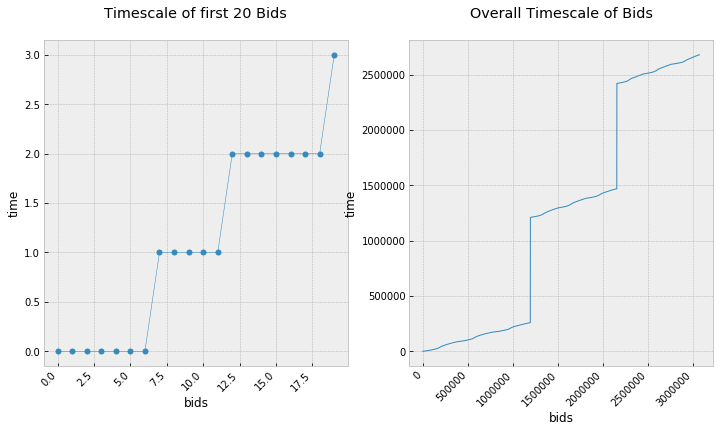

```python
# find the largest step
largest_step = np.max(steps)

big_step_indices = []

for i, t in enumerate(data_bids['time'][1:]):
    # get the difference of the two timestamps
    real_expected_diff = t - data_bids['time'][i]
    # test if this is one of the two cases
    if real_expected_diff == largest_step:
        big_step_indices.append((i, i+1))

print("The two pairs of indices for which there is the big step in between are: {} and {}."
      .format(big_step_indices[0], big_step_indices[1]))

# print(data_bids['time'][big_step_indices[0][0]])
# print(data_bids['time'][big_step_indices[0][1]])
# print(data_bids['time'][big_step_indices[1][0]])
# print(data_bids['time'][big_step_indices[1][1]])

# update the column
data_bids['time'] = data_bids['time'].div(step)

# find teh value of the huge step
huge_step_value_normalized = data_bids['time'][big_step_indices[0][1]] - \
                             data_bids['time'][big_step_indices[0][0]]

print("The huge step after the normalization is {}.".format(huge_step_value_normalized))

display(data_bids.head(10))

# plot the the shortened timeseries
plot_the_timeseries(data_bids['time'])
```

```python
print("The first period starts in timestamp {}.".format(data_bids['time'][0]))
print("The first period ends in timestamp {}.".format(data_bids['time'][1193269]))
print("(The in-between time was {} units of time.)"
      .format(data_bids['time'][1193269] - data_bids['time'][0]))
print("...")
print("--> Then there is a split for {} units of time."
      .format(data_bids['time'][1193270] - data_bids['time'][1193269]))
print("...")
print("The second period starts in timestamp {}.".format(data_bids['time'][1193270]))
print("The second period ends in in timestamp {}.".format(data_bids['time'][2153119]))
print("(The in-between time was {} units of time.)"
      .format(data_bids['time'][2153119] - data_bids['time'][1193270]))
print("...")
print("--> Then there is a split for {} units of time."
      .format(data_bids['time'][2153120] - data_bids['time'][2153119]))
print("...")
print("The third period starts in timestamp {}.".format(data_bids['time'][2153120]))
print("The third period ends in timestamp {}.".format(data_bids['time'][data_bids.shape[0]-1]))
print("(The in-between time was {} units of time.)"
      .format(data_bids['time'][data_bids.shape[0]-1] - data_bids['time'][2153120]))
```

```
The first period starts in timestamp 0.0.
The first period ends in timestamp 259198.999740802.
(The in-between time was 259198.999740802 units of time.)
...
--> Then there is a split for 950400.9990496009 units of time.
...
The second period starts in timestamp 1209599.998790403.
The second period ends in in timestamp 1468798.998531186.
(The in-between time was 259198.99974078313 units of time.)
...
--> Then there is a split for 950400.9990496011 units of time.
...
The third period starts in timestamp 2419199.997580787.
The third period ends in timestamp 2678398.997321589.
(The in-between time was 259198.99974080175 units of time.)
```

#### Features to be made with time column

Probably the best features for this project will be the ones that closely relate to time. That is because a bot will probably have a strategy on how to bid and it does not think or behaves randomly like a human which calls for a prolonged response in chaotic-like patterns.

From all the analysis of the timeseries we have so far made, it seems like the auctions platform has three biding periods that probably accounts for three days or three weeks or something like that. The main way to produce features from it would be by taking the timeseries and computing:

- the number of unique bids
- the ratio of simultaneous bids to all bids
- the timestamp of the earlies bid someone made (min)
- the timestamp of the latest bid someone made (max)
- the timestamp of the middle bid someone made (median)
- the mean timestamp of someone's bids (mean)
- the variance in timestamps of someones bids (std)

In addition to that there is a case to be made for the intervals, which capture the frequency with which someone bids. As far as intervals are concerned there are similar features we can build according to them:

- the number of periods someone participated in (did he participate in all periods/days/weeks?)
- the smallest interval (min)
- the biggest interval (max)
- the median interval (median)
- the mean interval (mean)
- the variance of intervals (std)

```python
def descriptive_stats(series):
    """ Takes a distribution and computes several descriptive statistic functions. """
    return np.min(series), np.max(series), np.median(series), np.mean(series), np.std(series)


def features_timeseries_simple(series, huge_gap_in_time, smaller_table=False):
    """ Produces 13 features for a timseries. The 7 first have to do with the timeseries,
    and the following 6 with a series of intervals from the timeseries."""

    # number of bids
    num_bids = series.shape[0]

    # find the ratio of how many bids did not happen simultaneously relative to all bids
    simultaneous_bid_ratio = 1 - (np.unique(series).shape[0] / series.shape[0])

    # find earliest bid of the user
    earliest_bid = np.min(series)

    # find latest bid of the user
    latest_bid = np.max(series)

    # find the timestamp of the bid in the middle
    middle_bid = np.median(series)

    # find the mean bid timestamp
    mean_bid_timestamp = np.mean(series)

    # find the std of the timestamp
    std_bid_timestamp = np.std(series)

    ######### Move on to the intervals stats #########

    # get the intervals between the timestamps
    intervals = series.sub(series.shift(1))

    # reduce the intervals shape
    intervals = intervals[1:] if intervals.shape[0] > 1 else intervals

    # find at which of the 3 periods a user participated in by the 2 possible gaps in time
    num_periods_participated_in = np.count_nonzero(intervals > huge_gap_in_time) + 1

    # remove those values
    intervals = intervals[intervals < huge_gap_in_time]

    if intervals.shape[0] > 1:

        # find the smallest interval
        smallest_interval = np.min(intervals)

        # find the biggest interval
        largest_interval = np.max(intervals)

        # find the median of the intervals
        median_intervals = np.median(intervals)

        # find the mean of the intervals
        mean_intervals = np.mean(intervals)

        # find the std of the intervals
        std_intervals = np.std(intervals)

    elif intervals.shape[0] <= 1 and not smaller_table:

        # set them as nan and filter them out later as rows
        smallest_interval, largest_interval, median_intervals, mean_intervals, std_intervals = \
        None, None, None, None, None

    else:

        # set them 0 as they will get filtered out
        smallest_interval, largest_interval, median_intervals, mean_intervals, std_intervals = \
        0, 0, 0, 0, 0

    return num_bids, simultaneous_bid_ratio, earliest_bid, latest_bid, middle_bid,\
            mean_bid_timestamp, std_bid_timestamp, num_periods_participated_in, smallest_interval,\
            largest_interval, median_intervals, mean_intervals, std_intervals
```

```python
# TEST CELL FOR features_time FUNCTION

np.set_printoptions(threshold=40)
pd.set_option('display.max_rows', 280)

for bidder, group in data_bids.groupby('bidder_id', sort=False):

    # 13 features for the standalone timeseries of a user
    a, b, c, d, e, f, g, aa, bb, cc, dd, ee, ff = \
    features_timeseries_simple(group['time'], huge_step_value_normalized-100)

    print("The features for the timeseries are: {}".format((a, b, c, d, e, f, g)))
    print("The features for the intervals are: {}".format((aa, bb, cc, dd, ee, ff)))

    break
```

```
The features for the timeseries are: (46707, 0.0867107714047145, 0.0, 1468748.998531243, 145824.999854175, 270361.0673854443, 400237.8940087036)
The features for the intervals are: (2, 0.0, 646.999999353895, 4.0, 11.097377143382912, 24.81366208706166)
```

#### Features to be made with time column and a grouping by unique ids of another column

In addition to those features that relate to time, suspicious timeseries patters might arise by bidders according to the auction they are betting on, or the country they are betting from. In order to capture that, we need to examine the timeseries in a case to case basis (e.g. auction to auction) and then we will have a distribution of for example, mins, maxs, means, medians etc. for each case. At these distributions we can also try find descriptive statistics, for example if we have a distribution of all means in the auctions a bidder participated in, we can then take some descriptive statistics for a distribuitions of lets say mins:

- the min of all mins,
- the max of all mins,
- the median of all mins,
- the mean of all mins,
- and the std of all mins,

and we can do the same thing for all 13 features we extract from a timeseries for which we will have distributions from.

That suggests that all 13 features for a timeseries that we discuss above can be applied to the case by case basis which will result into a distribution of each one of them. However, since we talked about 5 descriptive statistics of those distributions, and there are will be 13 of them, we are making the feature space explode as that accouns for 65 features, and if we run it with all categories, it would account for $65*6=390$ features. This could be counterable to an extend with some feature selection later on, or some robust algorithm to overfit like RF and long training time. In addition to that we might not run it with every category, because given what we have seen from merchandise category or ips and urls there is probably less meaningful to run it there.

```python
def features_time_with_grouping(df, second_category, huge_gap_in_time):
    """ Produces 65 features for multiple timeseries that can be found by grouping the bids of a
    bidder by categories like 'auction' or 'country'."""

    # initialize arrays for timeseries base stats
    num_bids = np.array([])
    rat_sim_bids = np.array([])
    series_mins = np.array([])
    series_maxs = np.array([])
    series_medians = np.array([])
    series_means = np.array([])
    series_stds = np.array([])

    # initialize arrays for interval base stats
    num_periods = np.array([])
    intervals_mins = np.array([])
    intervals_maxs = np.array([])
    intervals_medians = np.array([])
    intervals_means = np.array([])
    intervals_stds = np.array([])

    # group the dataframe by auctions
    for _, group in df.groupby(second_category):

        # 13 features for the standalone timeseries of a user
        a, b, c, d, e, f, g, aa, bb, cc, dd, ee, ff = \
        features_timeseries_simple(group['time'], huge_gap_in_time, smaller_table=True)

        # append timseries stats
        num_bids = np.append(num_bids, a)
        rat_sim_bids = np.append(rat_sim_bids, b)
        series_mins = np.append(series_mins, c)
        series_maxs = np.append(series_maxs, d)
        series_medians = np.append(series_medians, e)
        series_means = np.append(series_means, f)
        series_stds = np.append(series_stds, g)

        # append intervals stats
        num_periods = np.append(num_periods, aa)
        intervals_mins = np.append(intervals_mins, bb)
        intervals_maxs = np.append(intervals_maxs, cc)
        intervals_medians = np.append(intervals_medians, dd)
        intervals_means = np.append(intervals_means, ee)
        intervals_stds = np.append(intervals_stds, ff)

    # check how many zeros are in the array
    count_zeros = np.count_nonzero(intervals_means==0)

    if count_zeros and count_zeros!=intervals_means.shape[0]:
        # find the indices of all other numbers
        indices = np.where(intervals_means!=0)
        intervals_mins = intervals_mins[indices]
        intervals_maxs = intervals_maxs[indices]
        intervals_medians = intervals_medians[indices]
        intervals_means = intervals_means[indices]
        intervals_stds = intervals_stds[indices]

    # count all 13*5=65 features from here for every category according to timestamp

    # num_bids
    min_nbs, max_nbs, median_nbs, mean_nbs, std_nbs = descriptive_stats(num_bids)
    # rat_sim_bids
    min_rsb, max_rsb, median_rsb, mean_rsb, std_rsb = descriptive_stats(rat_sim_bids)
    # timeseries_mins
    min_mins_ts, max_mins_ts, median_mins_ts, mean_mins_ts, std_mins_ts = \
    descriptive_stats(series_mins)
    # timeseries_maxs
    min_maxs_ts, max_maxs_ts, median_maxs_ts, mean_maxs_ts, std_maxs_ts = \
    descriptive_stats(series_maxs)
    # timeseries_medians
    min_medians_ts, max_medians_ts, median_medians_ts, mean_medians_ts, std_medians_ts = \
    descriptive_stats(series_medians)
    # timeseries_means
    min_means_ts, max_means_ts, median_means_ts, mean_means_ts, std_means_ts = \
    descriptive_stats(series_means)
    # timeseries_stds
    min_stds_ts, max_stds_ts, median_stds_ts, mean_stds_ts, std_stds_ts = \
    descriptive_stats(series_stds)

    # num_periods
    min_nps, max_nps, median_nps, mean_nps, std_nps = descriptive_stats(num_periods)
    # intervals_mins
    min_mins_int, max_mins_int, median_mins_int, mean_mins_int, std_mins_int = \
    descriptive_stats(intervals_mins)
    # intervals_maxs
    min_maxs_int, max_maxs_int, median_maxs_int, mean_maxs_int, std_maxs_int = \
    descriptive_stats(intervals_maxs)
    # intervals_medians
    min_medians_int, max_medians_int, median_medians_int, mean_medians_int, std_medians_int = \
    descriptive_stats(intervals_medians)
    # intervals_means
    min_means_int, max_means_int, median_means_int, mean_means_int, std_means_int = \
    descriptive_stats(intervals_means)
    # intervals_stds
    min_stds_int, max_stds_int, median_stds_int, mean_stds_int, std_stds_int = \
    descriptive_stats(intervals_stds)

    return min_nbs, max_nbs, median_nbs, mean_nbs, std_nbs,\
            min_rsb, max_rsb, median_rsb, mean_rsb, std_rsb,\
            min_mins_ts, max_mins_ts, median_mins_ts, mean_mins_ts, std_mins_ts,\
            min_maxs_ts, max_maxs_ts, median_maxs_ts, mean_maxs_ts, std_maxs_ts,\
            min_medians_ts, max_medians_ts, median_medians_ts, mean_medians_ts, std_medians_ts,\
            min_means_ts, max_means_ts, median_means_ts, mean_means_ts, std_means_ts,\
            min_stds_ts, max_stds_ts, median_stds_ts, mean_stds_ts, std_stds_ts,\
            min_nps, max_nps, median_nps, mean_nps, std_nps,\
            min_mins_int, max_mins_int, median_mins_int, mean_mins_int, std_mins_int,\
            min_maxs_int, max_maxs_int, median_maxs_int, mean_maxs_int, std_maxs_int,\
            min_medians_int, max_medians_int, median_medians_int, mean_medians_int, std_medians_int,\
            min_means_int, max_means_int, median_means_int, mean_means_int, std_means_int,\
            min_stds_int, max_stds_int, median_stds_int, mean_stds_int, std_stds_int
```

```python
# TEST CELL FOR features_time FUNCTION

np.set_printoptions(threshold=40)
pd.set_option('display.max_rows', 280)

for bidder, group in data_bids.groupby('bidder_id', sort=False):

    # 65 features for timeseries per auction
    a, b, c, d, e, f, g, h, i, j, k, l, m, n, o, p, q, r, s, t, u, v, w, x, y, z, aa, bb, cc, dd,\
    ee, ff, gg, hh, ii, jj, kk, ll, mm, nn, oo, pp, qq, rr, ss, tt, uu, vv, ww, xx, yy, zz, aaa,\
    bbb, ccc, ddd, eee, fff, ggg, hhh, iii, jjj, kkk, lll, mmm = \
    features_time_with_grouping(group[['time', 'auction']],'auction', huge_step_value_normalized-100)

    print("The stats for number of bids are: {}".format((a, b, c, d, e)))
    print("The stats for ratios of simult bids are: {}".format((f, g, h, i, j)))
    print("The stats for number of periods are: {}".format((jj, kk, ll, mm, nn)))
    print("The stats for mins are: {}".format((oo, pp, qq, rr, ss)))
    print("The stats for maxs are: {}".format((tt, uu, vv, ww, xx)))
    print("The stats for medians are: {}".format((yy, zz, aaa, bbb, ccc)))
    print("The stats for means are: {}".format((ddd, eee, fff, ggg, hhh)))
    print("The stats for standard devs: {}".format((iii, jjj, kkk, lll, mmm)))

    print("\n------------------------------------------------------------------\n")

    # 65 features for timeseries per country
    a, b, c, d, e, f, g, h, i, j, k, l, m, n, o, p, q, r, s, t, u, v, w, x, y, z, aa, bb, cc, dd,\
    ee, ff, gg, hh, ii, jj, kk, ll, mm, nn, oo, pp, qq, rr, ss, tt, uu, vv, ww, xx, yy, zz, aaa,\
    bbb, ccc, ddd, eee, fff, ggg, hhh, iii, jjj, kkk, lll, mmm = \
    features_time_with_grouping(group[['time', 'country']],'country', huge_step_value_normalized-100)

    print("The stats for number of bids are: {}".format((a, b, c, d, e)))
    print("The stats for ratios of simult bids are: {}".format((f, g, h, i, j)))
    print("The stats for number of periods are: {}".format((jj, kk, ll, mm, nn)))
    print("The stats for mins are: {}".format((oo, pp, qq, rr, ss)))
    print("The stats for maxs are: {}".format((tt, uu, vv, ww, xx)))
    print("The stats for medians are: {}".format((yy, zz, aaa, bbb, ccc)))
    print("The stats for means are: {}".format((ddd, eee, fff, ggg, hhh)))
    print("The stats for standard devs: {}".format((iii, jjj, kkk, lll, mmm)))

    break
```

```
The stats for number of bids are: (1.0, 3918.0, 7.0, 124.22074468085107, 378.7907504873431)
The stats for ratios of simult bids are: (0.0, 0.15305313243457574, 0.0, 0.0016285759431374348, 0.010198620816563916)
The stats for number of periods are: (1.0, 2.0, 1.0, 1.3164893617021276, 0.4651062734811341)
The stats for mins are: (0.0, 55650.999944348994, 32.49999997150735, 2074.8385806023566, 6434.547613435172)
The stats for maxs are: (22.999999962048605, 207531.999792482, 51885.49994812999, 60166.62198707679, 46769.210040844744)
The stats for medians are: (3.0, 99611.499900383, 1737.7499982662462, 9133.751959370096, 18049.036459480536)
The stats for means are: (16.999999981024303, 99611.499900383, 5658.066661008423, 15024.418203957224, 20105.961403274392)
The stats for standard devs: (5.9999999810243025, 90299.24975647757, 10179.775954503086, 17308.634475431194, 19293.33350800879)

------------------------------------------------------------------

The stats for number of bids are: (1.0, 15318.0, 87.0, 864.9444444444445, 2233.9246432519594)
The stats for ratios of simult bids are: (0.0, 0.12486602357985, 0.0, 0.00486670045551811, 0.017501899537897974)
The stats for number of periods are: (1.0, 2.0, 2.0, 1.6111111111111112, 0.4874980215217845)
The stats for mins are: (0.0, 13190.999986814, 2.9999999809951987, 617.5106376797659, 2038.8972684678936)
The stats for maxs are: (6476.999993521, 186465.9998135341, 49085.999950904006, 57923.34036760818, 41285.53679013618)
The stats for medians are: (4.0, 36466.99996352001, 600.999999392021, 4471.436165740087, 8263.040460179926)
The stats for means are: (33.834225612548586, 47179.66661948967, 2762.3777750154945, 8890.147929672574, 12556.573306068938)
The stats for standard devs: (174.6275017711068, 64531.04484840872, 4791.324831892171, 12057.839405390905, 13866.912142893985)
```

#### Checking merchandise column

In addition to making timeseries features and adding features for the other dimensions, we will take a closer look into the merchandise column. It seems that most of the bidders had a unique merchandise because the mean merchandise was 1 and they had a very low std. If that is the case it means that it doesnt really help in identifying any pattern.

```python
# add the merchandise into a series to use value_counts() method
ss = pd.Series(merchandise_per_bidder, index=range(len(merchandise_per_bidder)))

# show the counts for each value
print(ss.value_counts())
```

```
1.0    1535
2.0       1
dtype: int64
```

**Interpretation:** As it seems there is only one bidder for whom there are two merchandise category and for the rest only one merchandise category is recorded. Maybe there are mistakes in data gathering or this is simply the case for this feature, but in any case it looks like this column should be dropped. However, before doing so it would be interesting to see a little bit how are the bot percentages within each category. Maybe we could consider adding this as a standalone categorical feature with 10 values, if there is one category that is heavily "contaminated" by bots.

#### Closer look into the merchandise category

Something that could be interesting to see before dropping the category is how many humans/bots are in each category. For example if in a certain category (which is a bit unlikely given the definition for merchandise column) there are a lot of bots then maybe the "merchandise category" could be a simple feature that worth using. To be able to visualize i made a *column_distributions* function that takes a column name and outputs a dictionary in the form:

d = **{'category': {'num_bidders': 0.0, 'perc_bots(%)': 0.0}, ... }**

After this, the *plot_stats_bar* function is made to use the dictionary information. It plots a bar for each category; the number of bidders that have done bets and are also in the category are represented as the length of the bar and the percentage of bots in a category is represented by a color mapping - the more red a bar is, the more dominated this category is by bots.

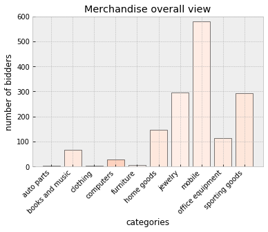

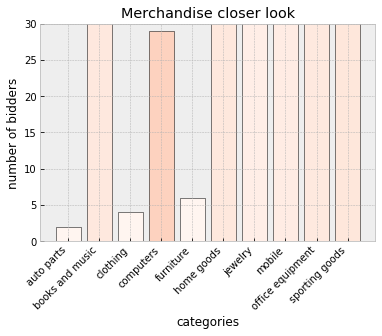

```
The raw dictionary is this:
{'auto parts': {'num_bidders': 2, 'perc_bots(%)': 0.0}, 'books and music': {'num_bidders': 67, 'perc_bots(%)': 7.462686567164178}, 'clothing': {'num_bidders': 4, 'perc_bots(%)': 0.0}, 'computers': {'num_bidders': 29, 'perc_bots(%)': 17.24137931034483}, 'furniture': {'num_bidders': 6, 'perc_bots(%)':…
```

```python
import matplotlib.cm as cm
import matplotlib.colors as col

def plot_stats_bar(items_d, figure_width, title, y_max):
    """ Plots a bar chart of colored points from a dictionary of the form:
    {'category': {'num_bidders': 0.0, 'perc_bots(%)': 0.0},  ... } """

    # get the categories in dictionary
    values_categories = [item[0] for item in items_d]
    # get the number of bidders (bar height) of the dictionary categories
    values_num_bidders = [item[1]['num_bidders'] for item in items_d]
    # get the percentage of bots (color intensity) of the dictionary categories
    bot_percentages = [item[1]['perc_bots(%)']*1 for item in items_d]
    # initialize figure axes and indices
    fig, ax = plt.subplots()

    # adjust the size of the figure
    fig.set_figwidth(figure_width)
    fig.set_figheight(4)

    # set axes
    ax.set_title('{}'.format(title))
    ax.set_xlabel('categories')
    ax.set_ylabel('number of bidders')
    ax.set_ylim([0, y_max])
    # get the labels to rotate them
    labels = ax.get_xticklabels()
    # rotate
    plt.setp(labels, rotation=45, horizontalalignment='right')

    # This is  the colormap I'd like to use.
    cmap = cm.ScalarMappable(col.Normalize(0, 99), cmap=plt.get_cmap('Reds'))
    # Plot histogram.
    ax = plt.bar(values_categories,
                 values_num_bidders, align='center', color=cmap.to_rgba(bot_percentages))
    # get the children
    for i, child in enumerate(ax.get_children()):
        # set the edgecolor for every bar
        child.set_edgecolor((0,0,0))

    plt.show()

def column_distributions(column_name):
    """ Accepts a categorical column of the data_bids table and finds its separate categories """
    # get merchandise categories
    categories = np.unique(data_bids[column_name])
    # get mask for '' country
    mask = np.isin(categories, list(control_set), invert=True)
    # remove ''
    categories = categories[mask]
    # make an empty internal dict for values
    cat_values = [{'num_bidders': None, 'perc_bots(%)': None} for x in range(categories.shape[0])]
    # initialize the dictionary to hold
    d = {k:v for (k,v) in zip(categories, cat_values)}

    for col, group in data_bids.groupby(column_name):

        if col=='' and column_name=='country':
            continue

        # get the unique bidder ids
        unique_bidders = np.unique(group['bidder_id'])
        # add the num_bidders for this merchandise
        d[col]['num_bidders'] = unique_bidders.shape[0]
        # find the counts of each outcome in the merchandise category
        counts = \
        data_bidders['outcome'].loc[data_bidders['bidder_id'].isin(unique_bidders)].value_counts()
        # get counts for 0
        counts_bots = counts[1] if 1 in counts.index else 0
        # update dict
        d[col]['perc_bots(%)'] = counts_bots/np.sum(counts)*100

    return d


# get the dictionary for the categories and their attributes
d1 = column_distributions('merchandise')

# plot the merchandise category bar
plot_stats_bar(d1.items(), 6, 'Merchandise overall view', 600)

# plot the merchandise category bar
plot_stats_bar(d1.items(), 6, 'Merchandise closer look', 30)

print('\n')
print('The raw dictionary is this:')
print(d1)
```

**Interpretation:** From the above it is obvious that there is very limited connection with the merchandise category and the presense bots. The only category that is slightly more "contaminated" is the "computers" one, but that is only a little bit. That makes some sense since a way that can be interpreted is "the ids that came to the site by an advertisment of computers are the most likely ones to be bots". However that is only 8.32% more than the second best category and 17.24% more than the worst. All that do need seem like there is a pattern here so i will drop this column.

```python
# drop the columns
data_bids.drop(columns=['merchandise'], inplace=True)

# confirm it happened
display(data_bids.head(3))
```

|  | bidder_id | auction | device | time | country | ip | url |
| --- | --- | --- | --- | --- | --- | --- | --- |
| 0 | 76218e14c379c12d599dae9e1c00b61a3i5b2 | 6hpvy | phone1161 | 0.0 | cz | 121.169.96.51 | f33fl83l4vrg6is |
| 1 | f5b2bbad20d1d7ded3ed960393bec0f40u6hn | 64uay | phone0 | 0.0 | ke | 17.120.130.121 | vasstdc27m7nks3 |
| 2 | f5b2bbad20d1d7ded3ed960393bec0f40u6hn | fagyq | phone1 | 0.0 | in | 161.192.187.34 | 3skc4v2r07bneta |

#### Closer look into the 'country' category

The same visualization is not easy to do with the rest of the columns due to the fact that they have a lot of parameters. But to some extend it is doable for country since it has up to 200 categories. That way we can see if there is a country that is highly "contaminated" with bots.

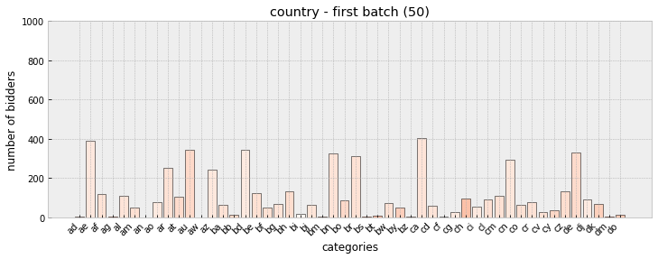

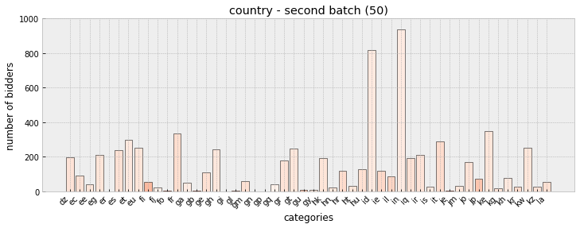

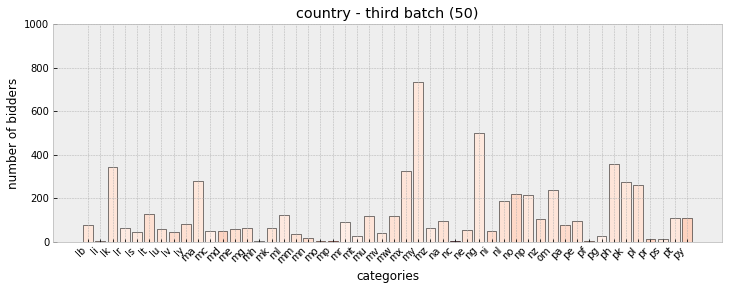

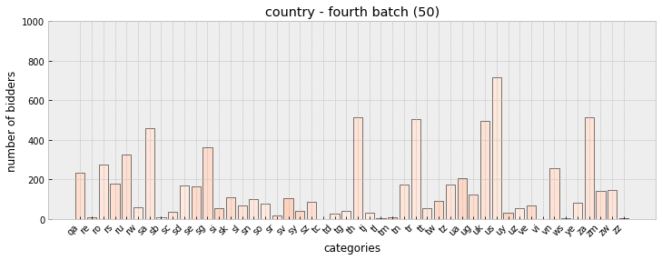

```python
# get the dictionary for the categories and their attributes
d2 = column_distributions('country')

# convert the iterable to list
items_d = list(d2.items())

# do the plots
plot_stats_bar(items_d[:50], 12, 'country - first batch (50)', 1000)
plot_stats_bar(items_d[50:100], 12, 'country - second batch (50)', 1000)
plot_stats_bar(items_d[100:150], 12, 'country - third batch (50)', 1000)
plot_stats_bar(items_d[150:], 12, 'country - fourth batch (50)', 1000)
```

**Interpretation:** From the above visualization we can also see that there is no country that shows higher margin of bots than humans. Especially the countries that many bidders have used them (like the ones with code names such as 'in', 'id', 'my' etc) probably - if anything - show that the users that use them are mostly humans by a decent margin. Usually some other countries like the ones with codes 'fi', 'ch', 'jp' etc seem to have bigger bot concertation.

However there are some cases with very few bidders which we do not really see. In order to see that better we can visualize it with a zoom at the bottom in the next cell.

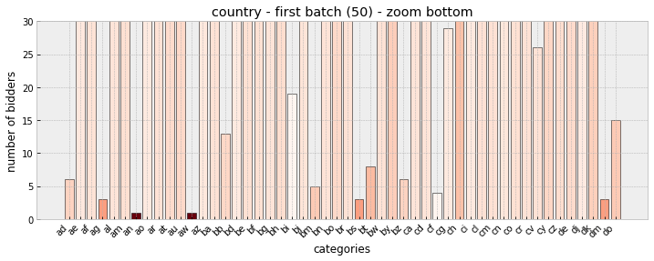

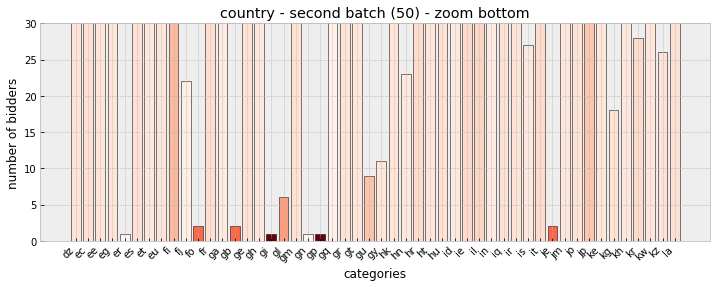

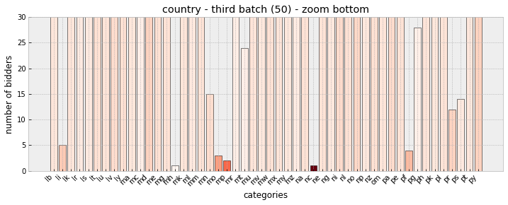

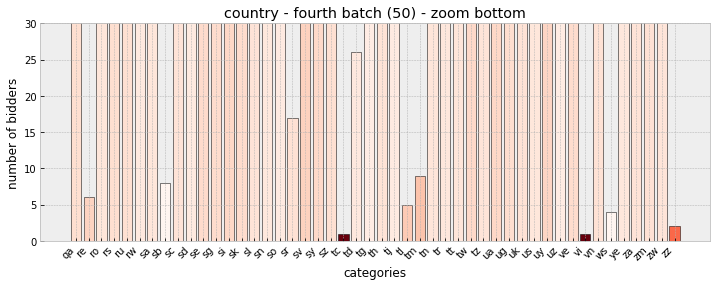

```python
# do the plots
plot_stats_bar(items_d[:50], 12, 'country - first batch (50) - zoom bottom', 30)
plot_stats_bar(items_d[50:100], 12, 'country - second batch (50) - zoom bottom', 30)
plot_stats_bar(items_d[100:150], 12, 'country - third batch (50) - zoom bottom', 30)
plot_stats_bar(items_d[150:], 12, 'country - fourth batch (50) - zoom bottom', 30)
```

**Interpretation:** Hereby it seems that mostly when the number of bidders is extremely small, there usually is a much better chance that the bidder will be a bot. Probably it is worth introducing a feature for a bidder like "betting from countries from where very few bets come".

#### Additional Exploration that can scale (1)

In addition to those plots we can also try visualize each column with regards to the counts of bidders and bids it contains. That will give an idea about the distribution of bidders and bids and will probably alert us in a case where there is a case like merchandise where there is for example a unique url in most cases or a device that appears in the hands of everyone, or an auction that holds most of the bids.

```
Each count of bidders is on the left and the countries it appears in, on the right:

     number of bidders  number of countries
0                  1.0                   10
1                  2.0                    5
2                  3.0                    4
3                  6.0                    4
4                 62.0                    4
5                  4.0                    3
6                  5.0                    3
7                 26.0                    3
8                 48.0                    3
9                 77.0                    3
..                 ...                  ...
129              391.0                    1
130              403.0                    1
131              459.0                    1
132              495.0                    1
133              500.0                    1
134              503.0                    1
135              715.0                    1
136              732.0                    1
137              819.0                    1
138              938.0                    1

[139 rows x 2 columns]
```

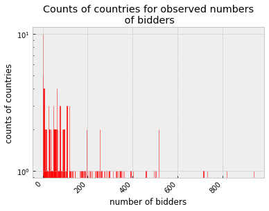

```
The highest count of bidders is 938.0 and it appears in 1 countries.
The lowest count of bidders is 1.0 and it appears in 10 countries.
42 of the 199 countries (which is 21.11%) have 77.0 bidders or less.


Each count of bids is on the left and the countries it appears in, on the right:

     number of bids  number of countries
0               1.0                    6
1              14.0                    4
2               6.0                    3
3               9.0                    3
4               4.0                    2
5               5.0                    2
6               8.0                    2
```

[output cut: 16 more lines]

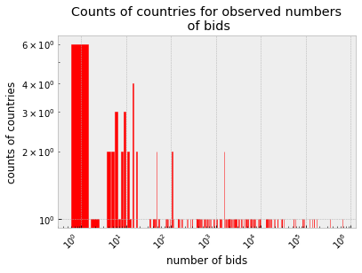

```
The highest count of bids is 645465.0 and it appears in 1 countries.
The lowest count of bids is 1.0 and it appears in 6 countries.
28 of the 199 countries (which is 14.07%) have 48.0 bids or less.
```

```python
# style
plt.style.use('bmh')

def plot_counts(x, y, counts_of, column, set_log_x=False, set_log_y=False):
    """ Plots the counts of a column in a bar chart. """

    # init the figure and the axes object
    fig, ax = plt.subplots(1, 1)
    # plot
    ax.bar(x, y, color='r', edgecolor='r')#, width=0.1
    # set text axes 1
    ax.set_title('Counts of {}s for observed numbers\n of {}'.format(column, counts_of))
    ax.set_xlabel('number of {}'.format(counts_of))
    ax.set_ylabel('counts of {}s'.format(column))
    ax.set_xscale('log') if set_log_x else None
    ax.set_yscale('log') if set_log_y else None
    # get the labels to rotate them
    labels = ax.get_xticklabels()
    # rotate
    plt.setp(labels, rotation=45, horizontalalignment='right')
    # show
    plt.show()

def describe_raw_categ_columns(column, counted_element):
    """ Aims to counts the values for bidders or bids (counted_element) of a column to
    describe it with bar chart plots. """

    if counted_element=='bidders' or counted_element=='bids':
        pass
    else:
        raise ValueError("The counted element should be either bids or bidders.")

    # set an option to display some of the counts series
    pd.set_option('display.max_rows', 20)

    if counted_element=='bidders':
        # get the count of the unique bidder ids of the group
        num_counts_per_element = data_bids.groupby(column, sort=False)['bidder_id'].nunique()
    else:
        # get the count of all bids of the group -> the 'country' doesnt matter, just to render obj
        num_counts_per_element = data_bids.groupby(column, sort=False)['country'].count()

    if column=='country':
        column = 'countrie'

    # get the counts
    cc = pd.Series(num_counts_per_element).value_counts()

    # transform to dataframe
    cc = pd.DataFrame({'number of {}'.format(counted_element):np.array([float(x) for x in cc.index]),
                        'number of {}s'.format(column):cc.values})

    # sort the counts according to both columns
    cc.sort_values(['number of {}s'.format(column), 'number of {}'.format(counted_element)],
                   ascending=[False, True], inplace=True)

    # set the index to properly reflect the iloc
    cc.set_index([list(range(cc.shape[0]))], inplace=True)

    print("Each count of {} is on the left and the {}s it appears in, on the right:\n\n{}\n"
          .format(counted_element, column, cc))

    # convert bidders or bids column to something easier to read and manipulate
    b = cc['number of {}'.format(counted_element)]
    # convert counts of the column element to something easier to read and manipulate
    counts = cc['number of {}s'.format(column)]

    if counted_element=='bidders':
        # plot counts for bidder ids
        plot_counts(b, counts, counted_element, column, set_log_x=False, set_log_y=True)
    else:
        # plot counts for bids
        plot_counts(b, counts, counted_element, column, set_log_x=True, set_log_y=True)

    print("The highest count of {} is {} and it appears in {} {}s."
          .format(counted_element, b.iloc[-1], counts.iloc[-1], column))
    print("The lowest count of {} is {} and it appears in {} {}s."
          .format(counted_element, b.iloc[0], counts.iloc[0], column))
    print("{} of the {} {}s (which is {:.2f}%) have {} {} or less."
          .format(counts[:10].sum(), counts.sum(), column, counts[:10].sum()/counts.sum()*100,
                  b.iloc[9], counted_element))
    print("\n")

# describe auctions with bidders
describe_raw_categ_columns('country', 'bidders')

# describe auctions with bids
describe_raw_categ_columns('country', 'bids')
```

**Interpretation:** This visualization in terms of bids mostly echoes the one we see above. The series has 179 rows because it seems that 20 countries have same counts of bids with other countries. Also there are a few countries that score very low and some that score extremely high in terms of bids. Now as far as bidders go (the first series-graph), we see that there are 25-30 countries that have a very few bidders that come from there (and they might overlap - we don't know from the grahps and info), but the big majority of countries seem to have many bidders which seems healthier in terms of bot "contamination".

#### Additional Exploration that can scale (2)

In addition to visualizing counts of bidders and bids, we can try to see the distribution of bots and humans to the populations.

```
Here is the Probability Density Function plot the bot/human groups of 'country' category:
```

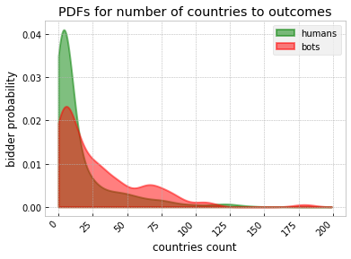

```python
from scipy.stats import gaussian_kde

def plot_outcome_area_with_num_of_elements(column, x_max=0):
    """ Plots an area for the two groups of outcomes and a category absolute numbers. """

    # bidders 0
    bidders_0 = data_bidders[['bidder_id', 'outcome']][data_bidders['outcome']==0]
    # bidders 1
    bidders_1 = data_bidders[['bidder_id', 'outcome']][data_bidders['outcome']==1]

    # init number of auctions column for humans
    bidders_0['num_auctions'] = np.nan
    # init number of auctions column for bots
    bidders_1['num_auctions'] = np.nan

    for bidder, group in data_bids.groupby('bidder_id'):

        if bidder in bidders_1['bidder_id'].values:
            bidders_1.loc[bidders_1['bidder_id']==bidder, 'num_auctions'] = group[column].nunique()
        else:
            bidders_0.loc[bidders_0['bidder_id']==bidder, 'num_auctions'] = group[column].nunique()

    # sort the counts according to both columns
    bidders_1.sort_values('num_auctions', ascending=True, inplace=True)
    # sort the counts according to both columns
    bidders_0.sort_values('num_auctions', ascending=True, inplace=True)

    # reset the index
    bidders_0.reset_index(drop=True, inplace=True)
    # reset the index
    bidders_1.reset_index(drop=True, inplace=True)

    # set the magnitude for x dimension of the plot
    xs_max = data_bids[column].nunique() if x_max==0 else x_max

    density_0 = gaussian_kde(bidders_0['num_auctions'])
    xs_0 = np.linspace(0, xs_max, 2000)
    density_0.covariance_factor = lambda : .25
    density_0._compute_covariance()

    density_1 = gaussian_kde(bidders_1['num_auctions'])
    xs_1 = np.linspace(0, xs_max, 2000)
    density_1.covariance_factor = lambda : .25
    density_1._compute_covariance()

    print("Here is the Probability Density Function plot the bot/human groups of '{}' category:"
          .format(column))

    if column=='country':
        column = 'countrie'

    # init the figure and the axes object
    fig, ax = plt.subplots(1, 1)

    # plot
    ax.fill_between(xs_0, density_0(xs_0), color='green', lw=2, alpha=0.5, edgecolor='b')
    ax.fill_between(xs_1, density_1(xs_1), color='red', lw=2, alpha=0.5, edgecolor='b')
    ax.set_facecolor((1, 1, 1))
    # set text axes 1
    ax.set_title('PDFs for number of {}s to outcomes'.format(column))
    ax.set_xlabel('{}s count'.format(column))
    ax.set_ylabel('bidder probability')
    ax.legend(['humans', 'bots'])
    # get the labels to rotate them
    labels = ax.get_xticklabels()
    # rotate
    plt.setp(labels, rotation=45, horizontalalignment='right')
    # show
    plt.show()

# plot the two outcome groups with the number of auctions
plot_outcome_area_with_num_of_elements('country')
```

**Interpretation:** As far as the density plot is concerned, it seems that there is not much to it as both functions peak at the same spot and that they are very heavily skewed on the left. However it seems that countries are probably important as there is a small peak to the bidders that bet from 50 to 100 countries, and generally bots seem more present to the higher values.

#### List of countries with a few bids

In addition to visuals, something that could help in making features from the countries column could be the number of small countries someone is making bids from. That is because we see that the countries that have the least bids are more "contaminated". In order to decide how many bids is low enough to put a country in the list, we considered two ways of doing it. The first one would be to look at the graphs and it seems that lower than 5 bids would maybe be the best number.

However this way we are leaking our knowledge of the data set too much into the model and it will for sure not generalize well. This would be a useless feature for example if we were building a model for the auctions platform and the bidding builds up and eventually there is no country with less than 5 bids. For that reason, as low activity countries we will consider the countries in the 1st Quartile in the distribution of numbers of bids.

```python
np.set_printoptions(threshold=100)

percentile = 25

def elements_with_low_bidders(data_bids, column, percentile=0, find_ones=False, highest_count=0):
    """ Finds the elements with low bidders """

    # get the series with country as index and the unique values count as value
    num_bidders_per_element = data_bids.groupby(column, sort=False)['bidder_id'].nunique()

    if percentile:

        # find the low threshold according to the first quartile
        low_threshold = np.percentile(num_bidders_per_element, percentile)

        # slice the list according to the low threshold
        countries_with_low_bidders = num_bidders_per_element[num_bidders_per_element<low_threshold]

    elif find_ones:

        # slice the list according to the low threshold
        countries_with_low_bidders = num_bidders_per_element[num_bidders_per_element==1]

    elif highest_count:

        # slice the list according to the low threshold
        countries_with_low_bidders = num_bidders_per_element[num_bidders_per_element<=highest_count]

    else:

        raise AttributeError("Need to specify either one of the attributes: percentile, \
find_ones, highest_count")

    return countries_with_low_bidders.shape[0], np.array(countries_with_low_bidders.index.tolist())

# apply the function for countries
num_countries_with_low_bidders, countries_with_low_bidders = \
                    elements_with_low_bidders(data_bids, 'country', percentile=percentile)

print("The {} countries with low bidders (below {}th percentile) are:\n{}"
      .format(num_countries_with_low_bidders, percentile, countries_with_low_bidders))
```

```
The 49 countries with low bidders (below 25th percentile) are:
['mn' 'pr' 'bi' 'cv' 'kz' 'td' 'kg' 'ad' 'bs' 'gy' 'mo' 'hn' 'li' 'aw'
 'mt' 'do' 'is' 're' 'sr' 'bb' 'gl' 'cf' 'ps' 'fj' 'je' 'dm' 'ag' 'vi'
 'nc' 'bm' 'bz' 'tm' 'pf' 'gu' 'ws' 'tl' 'tc' 'gb' 'mp' 'bt' 'sb' 'er'
 'fo' 'gp' 'zz' 'gn' 'an' 'gi' 'mh']
```

#### Features according to countries

First of all the country column can be used as a grouper when making features for time per bidder. The time patters of a bidder according to the country might be very telling on whether a user is a bot or human. In this group of features, the number of bids per country, the response times and other relevant things are considered.

Besides those, we will use some features that refer to the counts of countries. For example if a bidder makes bids from many countries, if we count how many bids are for each country we have a distribution of counts. Out of this distribution we can extract the following statistics:

- The number of countries the user is making bids from,
- the number of countries with few bidders (e.g. less than the 1st quartile) a bidder bids from,
- the count of the most used country relative to the count of all countries,
- the count of the least used country relative the the count of all countries,
- the mean count of countries,
- the median count of countries and,
- the std of the country counts

```python
def features_countries(series, low_bidder_countries,  num_countries_low):
    """ Produces the features that have to do with countries for a single bidder_id. """

    # get the counts
    counts = series.value_counts()
    # do stats
    counts_n = counts.shape[0]
    # number of countries with few bidders (normalized)
    counts_n_small = np.intersect1d(counts.index.values,
                                    low_bidder_countries).shape[0] / num_countries_low
    max_count = np.max(counts.values)
    min_count = np.min(counts.values)
    mean_count = np.mean(counts.values)
    median_count = np.median(counts.values)
    std_count = np.std(counts.values)

    return counts_n, counts_n_small, max_count, min_count, mean_count, median_count, std_count
```

```python
# TEST CELL FOR features_time FUNCTION

np.set_printoptions(threshold=40)
pd.set_option('display.max_rows', 280)

for bidder, group in data_bids.groupby('bidder_id', sort=False):

    # get country features per id
    a, b, c, d, e, f, g = features_countries(group['country'],
                                             countries_with_low_bidders,
                                             num_countries_with_low_bidders)

    print("The number of unique countries of bidder {}, is {}.".format(bidder, a))
    print("The percentage of non-active countries bidder {} bids from is {}.".format(bidder, b))
    print("The maximum count of countries of bidder {} is {}.".format(bidder, c))
    print("The minimum count of countries of bidder {} is {}.".format(bidder, d))
    print("The mean count of countries of bidder {} is {}.".format(bidder, e))
    print("The median count of countries of bidder {} is {}.".format(bidder, f))
    print("The std of counts of countries of bidder {} is {}.".format(bidder, g))

    print("\n------------------------------------------------------------------\n")

    # 65 features for timeseries per auction
    a, b, c, d, e, f, g, h, i, j, k, l, m, n, o, p, q, r, s, t, u, v, w, x, y, z, aa, bb, cc, dd,\
    ee, ff, gg, hh, ii, jj, kk, ll, mm, nn, oo, pp, qq, rr, ss, tt, uu, vv, ww, xx, yy, zz, aaa,\
    bbb, ccc, ddd, eee, fff, ggg, hhh, iii, jjj, kkk, lll, mmm = \
    features_time_with_grouping(group[['time', 'country']],'country', huge_step_value_normalized-100)

    print("The stats for number of bids are: {}".format((a, b, c, d, e)))
    print("The stats for ratios of simult bids are: {}".format((f, g, h, i, j)))
    print("The stats for number of periods are: {}".format((jj, kk, ll, mm, nn)))
    print("The stats for mins are: {}".format((oo, pp, qq, rr, ss)))
    print("The stats for maxs are: {}".format((tt, uu, vv, ww, xx)))
    print("The stats for medians are: {}".format((yy, zz, aaa, bbb, ccc)))
    print("The stats for means are: {}".format((ddd, eee, fff, ggg, hhh)))
    print("The stats for standard devs: {}".format((iii, jjj, kkk, lll, mmm)))

    break
```

```
The number of unique countries of bidder 76218e14c379c12d599dae9e1c00b61a3i5b2, is 54.
The percentage of non-active countries bidder 76218e14c379c12d599dae9e1c00b61a3i5b2 bids from is 0.02040816326530612.
The maximum count of countries of bidder 76218e14c379c12d599dae9e1c00b61a3i5b2 is 15318.
The minimum count of countries of bidder 76218e14c379c12d599dae9e1c00b61a3i5b2 is 1.
The mean count of countries of bidder 76218e14c379c12d599dae9e1c00b61a3i5b2 is 864.9444444444445.
The median count of countries of bidder 76218e14c379c12d599dae9e1c00b61a3i5b2 is 87.0.
The std of counts of countries of bidder 76218e14c379c12d599dae9e1c00b61a3i5b2 is 2233.9246432519594.

------------------------------------------------------------------

The stats for number of bids are: (1.0, 15318.0, 87.0, 864.9444444444445, 2233.9246432519594)
The stats for ratios of simult bids are: (0.0, 0.12486602357985, 0.0, 0.00486670045551811, 0.017501899537897974)
The stats for number of periods are: (1.0, 2.0, 2.0, 1.6111111111111112, 0.4874980215217845)
The stats for mins are: (0.0, 13190.999986814, 2.9999999809951987, 617.5106376797659, 2038.8972684678936)
The stats for maxs are: (6476.999993521, 186465.9998135341, 49085.999950904006, 57923.34036760818, 41285.53679013618)
The stats for medians are: (4.0, 36466.99996352001, 600.999999392021, 4471.436165740087, 8263.040460179926)
The stats for means are: (33.834225612548586, 47179.66661948967, 2762.3777750154945, 8890.147929672574, 12556.573306068938)
The stats for standard devs: (174.6275017711068, 64531.04484840872, 4791.324831892171, 12057.839405390905, 13866.912142893985)
```

### Closer look into the remaining categories

The remaining categories for a bidder are 'auction', 'device', 'url' and 'ip' and they are all categorical. We could try to do similar visualizations with the above but there is really a big amount of categories involved in order to extract something meaningful out of all the visualizations. In fact as we saw earlier, there is around 12.7k auctions, 5.7k devices ,1m ips and 663.5k urls and that probably makes the spacious bar plots not a very good idea as no category will be able to display clearly and no category also makes sense since they are either obfuscated or naturaly hard to categorize.

For that reason in the following sections we will make little plotting and then go into discussing features.

#### Explore auctions category

In the next cell we will explore the category with the defined functions above. Also we will get the list of the auctions with low bidders.

```
Each count of bidders is on the left and the auctions it appears in, on the right:

     number of auctions  number of bidders
0                  2939                1.0
1                  1838                2.0
2                  1163                3.0
3                   912                4.0
4                   674                5.0
5                   587                6.0
6                   478                7.0
7                   406                8.0
8                   364                9.0
9                   316               10.0
..                  ...                ...
127                   1              137.0
128                   1              142.0
129                   1              144.0
130                   1              158.0
131                   1              167.0
132                   1              168.0
133                   1              170.0
134                   1              198.0
135                   1              215.0
136                   1              305.0

[137 rows x 2 columns]
```

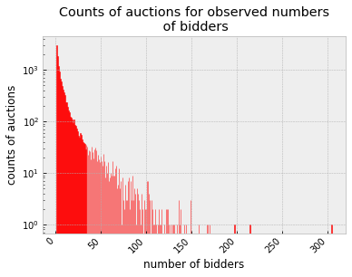

```
The highest count of bidders is 305.0 and it appears in 1 auctions.
The lowest count of bidders is 1.0 and it appears in 2939 auctions.
9677 of the 12740 auctions (which is 75.96%) have 10.0 bidders or less.


Each count of bids is on the left and the auctions it appears in, on the right:

      number of auctions  number of bids
0                   1486             1.0
1                    895             2.0
2                    621             3.0
3                    490             4.0
4                    426             5.0
5                    343             6.0
6                    288             7.0
```

[output cut: 16 more lines]

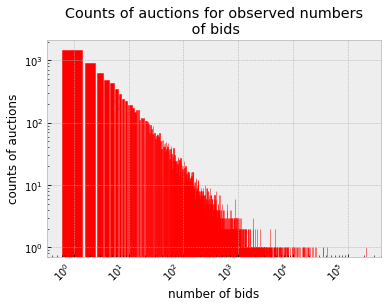

```
The highest count of bids is 217862.0 and it appears in 1 auctions.
The lowest count of bids is 1.0 and it appears in 1486 auctions.
5199 of the 12740 auctions (which is 40.81%) have 10.0 bids or less.


Here is the Probability Density Function plot the bot/human groups of 'auction' category:
```

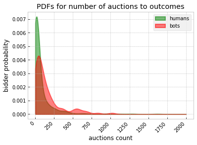

```
The 9677 auctions with 10 bidders or less are:
['64uay' 'i01xm' '5mqsv' ... '43qgg' '7rryo' 'c1ok3']
```

```python
# describe auctions with bidders
describe_raw_categ_columns('auction', 'bidders')

# describe auctions with bids
describe_raw_categ_columns('auction', 'bids')

# plot the two outcome groups with the number of auctions
plot_outcome_area_with_num_of_elements('auction', x_max=2000)

# apply the function for countries
num_auctions_with_low_bidders, auctions_with_low_bidders = \
                    elements_with_low_bidders(data_bids, 'auction', highest_count=10)

print("\n")
print("The {} auctions with 10 bidders or less are:\n{}"
      .format(num_auctions_with_low_bidders, auctions_with_low_bidders))
```

**Interpretation:** The bottom line of these plots is that few auctions captured the interest of the bidders. Particularly in the case of bidders, almost 76% of the auctions had 10 or less of them and almost 41% of the auctions had 10 bids or less. Also, the highest values for both distributions are pretty reasonable with 305 being the top bidder count and 217862 the highest one for bids (not sure if it is on the same auction tho). On a final note, the Probability Density Function says that probably there is nothing here, since both distributions seem to peak on the same spot.

#### Features according to auctions

First of all, similarly with countries, the auctions column can be used as a grouper when making features for time per bidder. The time patters of a bidder according to each auction might give out whether a user is a bot or human. In this group of features, the number of bids per auction, the response times and other relevant things are considered. Besides those, a few features that we can try out that include the auctions a bidder participated in could be:

Also, it is fair to say that given the plots earlier we can say that what happens seems like what would normaly happen, a few auctions to concertate the interest and many auctions strugling for attention. In that sense, maybe the non-temporal features will also be very interesting and probably good predictors for the robots. So, along with the temporal features we will use:

- The number of auctions someone participates in,
- the count of the most used auction relative to the count of all auctions,
- the count of the least used auction relative the the count of all auctions,
- the mean count of auctions,
- the median count of auctions and,
- the std of the auction counts

```python
def features_auctions(series):
    """ Produces the features that have to do with auctions for a single bidder_id. """

    # get the counts
    counts = series.value_counts()
    # do stats
    counts_n = counts.shape[0]
    max_count = np.max(counts.values)
    min_count = np.min(counts.values)
    mean_count = np.mean(counts.values)
    median_count = np.median(counts.values)
    std_count = np.std(counts.values)

    return counts_n, max_count, min_count, mean_count, median_count, std_count
```

```python
# TEST CELL FOR features_auctions FUNCTION

np.set_printoptions(threshold=40)
pd.set_option('display.max_rows', 280)

for bidder, group in data_bids.groupby('bidder_id', sort=False):

    # get auction features per id
    a, b, c, d, e, f = features_auctions(group['auction'])

    print("The number of auctions bidder {} has bid from is {}.".format(bidder, a))
    print("The maximum count of auctions of bidder {} is {}.".format(bidder, b))
    print("The minimum count of auctions of bidder {} is {}.".format(bidder, c))
    print("The mean count of auctions of bidder {} is {}.".format(bidder, d))
    print("The median count of auctions of bidder {} is {}.".format(bidder, e))
    print("The std of counts of auctions of bidder {} is {}.".format(bidder, f))

    print("\n------------------------------------------------------------------\n")

    # 65 features for timeseries per auction
    a, b, c, d, e, f, g, h, i, j, k, l, m, n, o, p, q, r, s, t, u, v, w, x, y, z, aa, bb, cc, dd,\
    ee, ff, gg, hh, ii, jj, kk, ll, mm, nn, oo, pp, qq, rr, ss, tt, uu, vv, ww, xx, yy, zz, aaa,\
    bbb, ccc, ddd, eee, fff, ggg, hhh, iii, jjj, kkk, lll, mmm = \
    features_time_with_grouping(group[['time', 'auction']],'auction', huge_step_value_normalized-100)

    print("The stats for number of bids are: {}".format((a, b, c, d, e)))
    print("The stats for ratios of simult bids are: {}".format((f, g, h, i, j)))
    print("The stats for number of periods are: {}".format((jj, kk, ll, mm, nn)))
    print("The stats for mins are: {}".format((oo, pp, qq, rr, ss)))
    print("The stats for maxs are: {}".format((tt, uu, vv, ww, xx)))
    print("The stats for medians are: {}".format((yy, zz, aaa, bbb, ccc)))
    print("The stats for means are: {}".format((ddd, eee, fff, ggg, hhh)))
    print("The stats for standard devs: {}".format((iii, jjj, kkk, lll, mmm)))

    break
```

```
The number of auctions bidder 76218e14c379c12d599dae9e1c00b61a3i5b2 has bid from is 376.
The maximum count of auctions of bidder 76218e14c379c12d599dae9e1c00b61a3i5b2 is 3918.
The minimum count of auctions of bidder 76218e14c379c12d599dae9e1c00b61a3i5b2 is 1.
The mean count of auctions of bidder 76218e14c379c12d599dae9e1c00b61a3i5b2 is 124.22074468085107.
The median count of auctions of bidder 76218e14c379c12d599dae9e1c00b61a3i5b2 is 7.0.
The std of counts of auctions of bidder 76218e14c379c12d599dae9e1c00b61a3i5b2 is 378.7907504873431.

------------------------------------------------------------------

The stats for number of bids are: (1.0, 3918.0, 7.0, 124.22074468085107, 378.7907504873431)
The stats for ratios of simult bids are: (0.0, 0.15305313243457574, 0.0, 0.0016285759431374348, 0.010198620816563916)
The stats for number of periods are: (1.0, 2.0, 1.0, 1.3164893617021276, 0.4651062734811341)
The stats for mins are: (0.0, 55650.999944348994, 32.49999997150735, 2074.8385806023566, 6434.547613435172)
The stats for maxs are: (22.999999962048605, 207531.999792482, 51885.49994812999, 60166.62198707679, 46769.210040844744)
The stats for medians are: (3.0, 99611.499900383, 1737.7499982662462, 9133.751959370096, 18049.036459480536)
The stats for means are: (16.999999981024303, 99611.499900383, 5658.066661008423, 15024.418203957224, 20105.961403274392)
The stats for standard devs: (5.9999999810243025, 90299.24975647757, 10179.775954503086, 17308.634475431194, 19293.33350800879)
```

#### Explore devices category

In the next cell we will explore the category with the defined functions above. Also we will get the list of the devices with low bidders.

```
Each count of bidders is on the left and the devices it appears in, on the right:

     number of bidders  number of devices
0                  1.0               1580
1                  2.0                644
2                  3.0                460
3                  4.0                315
4                  5.0                248
5                  6.0                187
6                  7.0                148
7                  8.0                131
8                  9.0                109
9                 10.0                 93
..                 ...                ...
331              627.0                  1
332              635.0                  1
333              651.0                  1
334              668.0                  1
335              670.0                  1
336              675.0                  1
337              684.0                  1
338              689.0                  1
339              751.0                  1
340              879.0                  1

[341 rows x 2 columns]
```

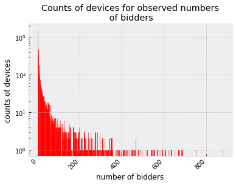

```
The highest count of bidders is 879.0 and it appears in 1 devices.
The lowest count of bidders is 1.0 and it appears in 1580 devices.
3915 of the 5728 devices (which is 68.35%) have 10.0 bidders or less.


Each count of bids is on the left and the devices it appears in, on the right:

     number of bids  number of devices
0               1.0               1110
1               2.0                512
2               3.0                331
3               4.0                253
4               5.0                184
5               6.0                179
6               7.0                133
```

[output cut: 16 more lines]

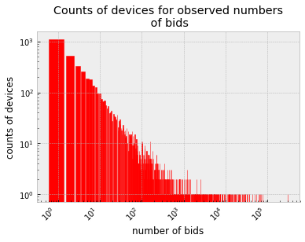

```
The highest count of bids is 306966.0 and it appears in 1 devices.
The lowest count of bids is 1.0 and it appears in 1110 devices.
3016 of the 5728 devices (which is 52.65%) have 10.0 bids or less.


Here is the Probability Density Function plot the bot/human groups of 'device' category:
```

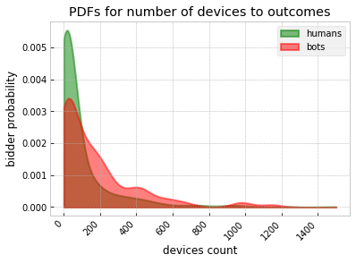

```
The 3915 devices with 10 bidders or less are:
['phone883' 'phone857' 'phone4204' ... 'phone5357' 'phone5393' 'phone5394']
```

```python
# describe devices with bidders
describe_raw_categ_columns('device', 'bidders')

# describe devices with bids
describe_raw_categ_columns('device', 'bids')

# plot the two outcome groups with the number of devices
plot_outcome_area_with_num_of_elements('device', x_max=1500)

# apply the function for devices
num_devices_with_low_bidders, devices_with_low_bidders = \
                    elements_with_low_bidders(data_bids, 'device', highest_count=10)

print("\n")
print("The {} devices with 10 bidders or less are:\n{}"
      .format(num_devices_with_low_bidders, devices_with_low_bidders))
```

In addition to that, it seems that the highest values for the bidders distribution seems reasonable (879 users used the same phone brand), while the bids one not (307k bids by one phone brand! maybe that brand can easily carry bot software or something). Finally, the Probability Density Function says that probably there is nothing here also, since both distributions seem to peak on the same spot again - similar with the other two cases.

#### Features according to devices

First, similarly with countries and auctions, the devices column can be used as a grouper when making features for time per bidder. The time patters of a bidder according to each of his devices might give out whether a user is a bot or human. In this group of features, the number of bids per device, the response times and other relevant things are considered. Besides those, a few features that we can try out are:

Also, just like with the two previous cases, we cannot say that these statistics or plots gave us any new insights as this seems like what would normaly happen, a some devices are moderately popular and some others not so much. In that sense, we will also use some features that are regarding to counts like:

- The number of devices someone has used,
- the count of the most used device,
- the count of the least used device,
- the mean count of devices,
- the median count of devices and,
- the std of the device counts

```python
def features_devices(series):
    """ Produces the features that have to do with devices for a single bidder_id. """

    # get the counts
    counts = series.value_counts()
    # do stats
    counts_n = counts.shape[0]
    max_count = np.max(counts.values)
    min_count = np.min(counts.values)
    mean_count = np.mean(counts.values)
    median_count = np.median(counts.values)
    std_count = np.std(counts.values)

    return counts_n, max_count, min_count, mean_count, median_count, std_count
```

```python
# TEST CELL FOR features_devices FUNCTION

np.set_printoptions(threshold=40)
pd.set_option('display.max_rows', 280)

for bidder, group in data_bids.groupby('bidder_id', sort=False):

    # get device features per id
    a, b, c, d, e, f = features_devices(group['device'])

    print("The number of devices bidder {} has bid from is {}.".format(bidder, a))
    print("The maximum count of devices of bidder {} is {}.".format(bidder, b))
    print("The minimum count of devices of bidder {} is {}.".format(bidder, c))
    print("The mean count of devices of bidder {} is {}.".format(bidder, d))
    print("The median count of devices of bidder {} is {}.".format(bidder, e))
    print("The std of counts of devices of bidder {} is {}.".format(bidder, f))

    print("\n------------------------------------------------------------------\n")

    # 65 features for timeseries per device
    a, b, c, d, e, f, g, h, i, j, k, l, m, n, o, p, q, r, s, t, u, v, w, x, y, z, aa, bb, cc, dd,\
    ee, ff, gg, hh, ii, jj, kk, ll, mm, nn, oo, pp, qq, rr, ss, tt, uu, vv, ww, xx, yy, zz, aaa,\
    bbb, ccc, ddd, eee, fff, ggg, hhh, iii, jjj, kkk, lll, mmm = \
    features_time_with_grouping(group[['time', 'device']],'device', huge_step_value_normalized-100)

    print("The stats for number of bids are: {}".format((a, b, c, d, e)))
    print("The stats for ratios of simult bids are: {}".format((f, g, h, i, j)))
    print("The stats for number of periods are: {}".format((jj, kk, ll, mm, nn)))
    print("The stats for mins are: {}".format((oo, pp, qq, rr, ss)))
    print("The stats for maxs are: {}".format((tt, uu, vv, ww, xx)))
    print("The stats for medians are: {}".format((yy, zz, aaa, bbb, ccc)))
    print("The stats for means are: {}".format((ddd, eee, fff, ggg, hhh)))
    print("The stats for standard devs: {}".format((iii, jjj, kkk, lll, mmm)))

    break
```

```
The number of devices bidder 76218e14c379c12d599dae9e1c00b61a3i5b2 has bid from is 1241.
The maximum count of devices of bidder 76218e14c379c12d599dae9e1c00b61a3i5b2 is 13623.
The minimum count of devices of bidder 76218e14c379c12d599dae9e1c00b61a3i5b2 is 1.
The mean count of devices of bidder 76218e14c379c12d599dae9e1c00b61a3i5b2 is 37.63658340048348.
The median count of devices of bidder 76218e14c379c12d599dae9e1c00b61a3i5b2 is 4.0.
The std of counts of devices of bidder 76218e14c379c12d599dae9e1c00b61a3i5b2 is 396.0950112491108.

------------------------------------------------------------------

The stats for number of bids are: (1.0, 13623.0, 4.0, 37.63658340048348, 396.0950112491108)
The stats for ratios of simult bids are: (0.0, 0.0254716288629524, 0.0, 7.102217166985047e-05, 0.000926012000583536)
The stats for number of periods are: (1.0, 2.0, 1.0, 1.379532634971797, 0.4852706605216945)
The stats for mins are: (0.0, 105296.99989470199, 168.9999998385083, 4384.609191017801, 11749.472595007455)
The stats for maxs are: (25.999999980907887, 243994.99975600187, 77399.999922594, 82010.2786536214, 44089.244306326684)
The stats for medians are: (9.0, 121600.9998784, 9098.749990903743, 19891.252853672253, 25159.486937112237)
The stats for means are: (14.666666654016202, 121600.9998784, 19775.791646890553, 26802.75944358265, 24016.671167453325)
The stats for standard devs: (8.055363977084506, 118145.999881858, 20807.901134701977, 25429.094044086163, 19136.599952710443)
```

#### Explore url category

In the next cell we will explore the category for urls with the functions defined earlier. Also we will get the list of the urls with low bidders.

```
Each count of bidders is on the left and the urls it appears in, on the right:

    number of bidders  number of urls
0                 1.0          646147
1                 2.0           14470
2                 3.0            2400
3                 4.0             426
4                 5.0              84
5                 6.0              13
6                 7.0               9
7                 8.0               3
8                 9.0               3
9                10.0               2
10               11.0               1
11               14.0               1
12               21.0               1
13             1378.0               1
```

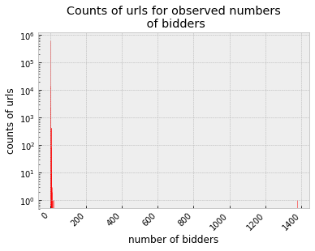

```
The highest count of bidders is 1378.0 and it appears in 1 urls.
The lowest count of bidders is 1.0 and it appears in 646147 urls.
663557 of the 663561 urls (which is 100.00%) have 10.0 bidders or less.


Each count of bids is on the left and the urls it appears in, on the right:

     number of bids  number of urls
0               1.0          552143
1               2.0           55271
2               3.0           18371
3               4.0            9384
4               5.0            5610
5               6.0            3671
6               7.0            2673
```

[output cut: 16 more lines]

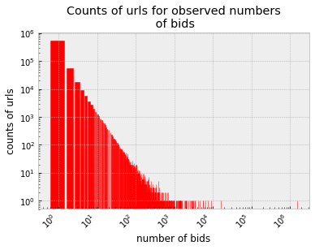

```
The highest count of bids is 1545806.0 and it appears in 1 urls.
The lowest count of bids is 1.0 and it appears in 552143 urls.
651851 of the 663561 urls (which is 98.24%) have 10.0 bids or less.


Here is the Probability Density Function plot the bot/human groups of 'url' category:
```

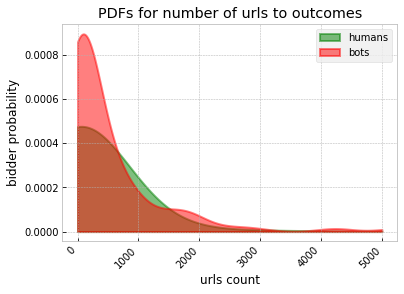

```
The 663557 urls with 10 bidders or less are:
['f33fl83l4vrg6is' '3skc4v2r07bneta' 'eovsi6u99d9b72w' ...
 'dapbzyutdrdsxg1' 'svwa4jbb4pfd2fo' 'rpt2umq2eorj5nb']
```

```python
# describe urls with bidders
describe_raw_categ_columns('url', 'bidders')

# describe urls with bids
describe_raw_categ_columns('url', 'bids')

# plot the two outcome groups with the number of urls
plot_outcome_area_with_num_of_elements('url', x_max=5000)

# apply the function for urls
num_urls_with_low_bidders, urls_with_low_bidders = \
                    elements_with_low_bidders(data_bids, 'url', highest_count=10)

print("\n")
print("The {} urls with 10 bidders or less are:\n{}"
      .format(num_urls_with_low_bidders, urls_with_low_bidders))
```

**Interpretation:** The first thing we can observe from the url stats with bidders is that the vast majority of bidders (around than 89.7%) has used a very specific url, and on the contrary the vast majority of urls (around 97.4%) have been used by a single bidder. In that sense they are unique to a bidder and that probably makes them less interesting from one aspect. A remaining 2.8% (or close to that) is in a grey area of urls that have been used by multiple people (one of them almost by the entire bidderbase).

Each of them was for a particular bid so we cannot assume that maybe they are probably urls not for betting or something like that. One thing we could think of though is that there might be some kind of problem with the data because in order to make a bid you have to send a unique url, at least to signal to the platforms backend that he is a different person. It is hard to imagine how two different people can use the same url even if they are betting on the same time, for the same exact auction since by definition they are two different people.

However according to the PDF the urls with the most bidders probably have the most malicious ones.

Also in terms of the bids, it seems that logically, around 83.21% of urls have a unique bid. The cases that have more bids are probably from the same people. There is also one crazy url that has been used for 1.5m bids (out of the 3m). Other cases of urls used for a big amount of bids are seemingly many, but much less than 1.5m, and more like 3k bids.

#### Features according to urls

When making features for urls, it is needed for the picture shown from the above plots to be taken into account. Probably urls can give us a simple and powerful feature which is the count of urls for each bidder. That is because we saw that the common place is that one url is usually connected with a bidder or a bid. When the count of bids, is ridiculusly high that is probably alarming, but that is not the case with the count of bidders.

On the contrary because the count of bidders was high at some points we might think that the url data might not be documented well or there might be something we don't know for the website. It might be the case that the personal data are being extracted by the cookie and the url is standardized, given that this is how cookies work with urls etc.

An additional thing, looking at the grand scale of the dataset, there are around 3m bids and 663k urls which means that the user is not doing too many things with one url, as it burns out to a few bids. There is not much to the users behavior with it. That is the main reason for i will not use the timeseries features with them. Instead the features i will use will be:

- The number of different urls someone has bid from, normalized by the number of all urls (number of all the bidders bids),
- the count of the most used url relative to the count of all urls,
- the count of the least used url relative the the count of all urls,
- the mean count of urls,
- the median count of urls and,
- the std of the url counts

```python
def features_urls(series):
    """ Produces the features that have to do with urls for a single bidder_id. """

    # get the count
    counts = series.value_counts()
    # do stats
    counts_n = counts.shape[0]
    max_count = np.max(counts.values)
    min_count = np.min(counts.values)
    mean_count = np.mean(counts.values)
    median_count = np.median(counts.values)
    std_count = np.std(counts.values)

    return counts_n, max_count, min_count, mean_count, median_count, std_count
```

```python
# TEST CELL FOR features_urls FUNCTION

np.set_printoptions(threshold=40)
pd.set_option('display.max_rows', 280)

for bidder, group in data_bids.groupby('bidder_id', sort=False):

    # get urls features per id
    a, b, c, d, e, f = features_urls(group['url'])

    print("The number of unique urls of bidder {}, is {}.".format(bidder, a))
    print("The maximum count of urls of bidder {} is {}.".format(bidder, b))
    print("The minimum count of urls of bidder {} is {}.".format(bidder, c))
    print("The mean count of urls of bidder {} is {}.".format(bidder, d))
    print("The median count of urls of bidder {} is {}.".format(bidder, e))
    print("The std of counts of urls of bidder {} is {}.".format(bidder, f))

    break
```

```
The number of unique urls of bidder 76218e14c379c12d599dae9e1c00b61a3i5b2, is 9830.
The maximum count of urls of bidder 76218e14c379c12d599dae9e1c00b61a3i5b2 is 28831.
The minimum count of urls of bidder 76218e14c379c12d599dae9e1c00b61a3i5b2 is 1.
The mean count of urls of bidder 76218e14c379c12d599dae9e1c00b61a3i5b2 is 4.75147507629705.
The median count of urls of bidder 76218e14c379c12d599dae9e1c00b61a3i5b2 is 1.0.
The std of counts of urls of bidder 76218e14c379c12d599dae9e1c00b61a3i5b2 is 290.8441566966738.
```

#### Explore ip category

In the next cell we will explore the category for ips with the functions defined earlier. Also we will get the list of the ips with low bidders.

```
Each count of bidders is on the left and the ips it appears in, on the right:

     number of bidders  number of ips
0                  1.0         909645
1                  2.0          83830
2                  3.0          18185
3                  4.0           6238
4                  5.0           2982
5                  6.0           1709
6                  7.0           1182
7                  8.0            875
8                  9.0            683
9                 10.0            553
..                 ...            ...
137              137.0              1
138              141.0              1
139              143.0              1
140              146.0              1
141              147.0              1
142              153.0              1
143              156.0              1
144              172.0              1
145              175.0              1
146              185.0              1

[147 rows x 2 columns]
```

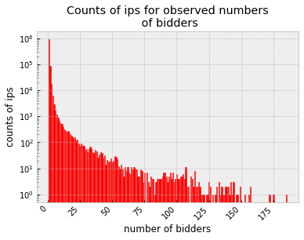

```
The highest count of bidders is 185.0 and it appears in 1 ips.
The lowest count of bidders is 1.0 and it appears in 909645 ips.
1025882 of the 1030732 ips (which is 99.53%) have 10.0 bidders or less.


Each count of bids is on the left and the ips it appears in, on the right:

     number of bids  number of ips
0               1.0         790388
1               2.0         139880
2               3.0          44555
3               4.0          18852
4               5.0           9492
5               6.0           5708
6               7.0           3643
```

[output cut: 16 more lines]

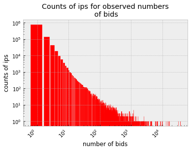

```
The highest count of bids is 37658.0 and it appears in 1 ips.
The lowest count of bids is 1.0 and it appears in 790388 ips.
1018052 of the 1030732 ips (which is 98.77%) have 10.0 bids or less.


Here is the Probability Density Function plot the bot/human groups of 'ip' category:
```

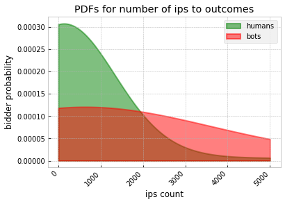

```
The 1025882 ips with 10 bidders or less are:
['121.169.96.51' '17.120.130.121' '161.192.187.34' ... '120.102.67.150'
 '82.55.221.65' '64.78.53.112']
```

```python
# describe ips with bidders
describe_raw_categ_columns('ip', 'bidders')

# describe ips with bids
describe_raw_categ_columns('ip', 'bids')

# plot the two outcome groups with the number of ips
plot_outcome_area_with_num_of_elements('ip', x_max=5000)

# apply the function for ips
num_ips_with_low_bidders, ips_with_low_bidders = \
                    elements_with_low_bidders(data_bids, 'ip', highest_count=10)

print("\n")
print("The {} ips with 10 bidders or less are:\n{}"
      .format(num_ips_with_low_bidders, ips_with_low_bidders))
```

**Interpretation:** Similarly to the ips, we can see here that around 90% of the ips are mapped 1 to 1 with the bidders. Also, there are probably more than 10k cases where several ips are shared with multiple bidders. That is a bit strange since it means that in a good amount of the bidderbase, an ip is shared by multiple people, and while it is something that can for sure happen as people share internet etc it seems a bit too frequent here.

#### Features according to ips

Similar to urls, the picture painted by these plots is that by large ips are mapped to a single user. However, there are more cases in ips than the urls where ips have been used by more than one person, which is logical to an extend. Also there are more cases where something is being used by multiple people which also makes sense since urls are more personalized to a specific bidder account.

Regarding the features, once again we will not use the timeseries features with the ips. That is because, even more than the urls, there are 1m ips and 3m bids, which means that in most cases there is hardly any time for a behavioral pattern to be captured and prove meaningful. Instead, we will use:

- The number of different ips someone has bid from, normalized by the number of all ips (number of all the bidders bids),
- the count of the most used ip relative to the count of all ips,
- the count of the least used ip relative the the count of all ips,
- the mean count of ips,
- the median count of ips and,
- the std of the counts

```python
def features_ips(series):
    """ Produces the features that have to do with ips for a single bidder_id. """

    # get the count
    counts = series.value_counts()
    # do stats
    counts_n = counts.shape[0]
    max_count = np.max(counts.values)
    min_count = np.min(counts.values)
    mean_count = np.mean(counts.values)
    median_count = np.median(counts.values)
    std_count = np.std(counts.values)

    return counts_n, max_count, min_count, mean_count, median_count, std_count
```

```python
# TEST CELL FOR features_ips FUNCTION

np.set_printoptions(threshold=40)
pd.set_option('display.max_rows', 280)

for bidder, group in data_bids.groupby('bidder_id', sort=False):

    # get ips features per id
    a, b, c, d, e, f = features_ips(group['ip'])

    print("The number of unique ips of bidder {}, is {}.".format(bidder, a))
    print("The maximum count of ips of bidder {} is {}.".format(bidder, b))
    print("The minimum count of ips of bidder {} is {}.".format(bidder, c))
    print("The mean count of ips of bidder {} is {}.".format(bidder, d))
    print("The median count of ips of bidder {} is {}.".format(bidder, e))
    print("The std of counts of ips of bidder {} is {}.".format(bidder, f))

    break
```

```
The number of unique ips of bidder 76218e14c379c12d599dae9e1c00b61a3i5b2, is 8343.
The maximum count of ips of bidder 76218e14c379c12d599dae9e1c00b61a3i5b2 is 2915.
The minimum count of ips of bidder 76218e14c379c12d599dae9e1c00b61a3i5b2 is 1.
The mean count of ips of bidder 76218e14c379c12d599dae9e1c00b61a3i5b2 is 5.598345918734268.
The median count of ips of bidder 76218e14c379c12d599dae9e1c00b61a3i5b2 is 1.0.
The std of counts of ips of bidder 76218e14c379c12d599dae9e1c00b61a3i5b2 is 46.29695727892956.
```

### Feature Production

The features i will use for this project will be all the features that were made specifically for the separate columns which are:

- The 13 timeseries features for of 'time' column
- the 7 features for 'country' category
- the 6 features for each of the 'auction', 'device', 'url', 'ip' columns (24 features in total),
- and the 65 features created for the timeseries of 'auction' column *

**The reason we did not use the extra timeseries features for 'country', 'device', 'url', 'ip' is that by trial and error we saw that 'auction' is the category that yields the best results and that we want to keep the dimensionality to a reasonable number*

```python
np.set_printoptions(threshold=40)
pd.set_option('display.max_rows', 280)

# initialize the 2d array that will hold all data
results = []

counter = 0

start = time()

for bidder, group in data_bids.groupby('bidder_id', sort=False):

    # initialize the row that will hold all features for the bidder
    row = [bidder]

    # 13 features for the standalone timeseries of a user
    a, b, c, d, e, f, g, aa, bb, cc, dd, ee, ff = \
    features_timeseries_simple(group['time'], huge_step_value_normalized-100)

#     print("The features for the timeseries are: {}".format((a, b, c, d, e, f, g)))
#     print("The features for the intervals are: {}".format((aa, bb, cc, dd, ee, ff)))

    # make the append
    row.extend([a, b, c, d, e, f, g, aa, bb, cc, dd, ee, ff])

#     print("\n------------------------------------------------------------------\n")

    # get country features per id
    a, b, c, d, e, f, g = features_countries(group['country'],
                                             countries_with_low_bidders,
                                             num_countries_with_low_bidders)

#     print("The number of unique countries of bidder {}, is {}.".format(bidder, a))
#     print("The percentage of non-active countries bidder {} bids from is {}.".format(bidder, b))
#     print("The maximum count of countries of bidder {} is {}.".format(bidder, c))
#     print("The minimum count of countries of bidder {} is {}.".format(bidder, d))
#     print("The mean count of countries of bidder {} is {}.".format(bidder, e))
#     print("The median count of countries of bidder {} is {}.".format(bidder, f))
#     print("The std of counts of countries of bidder {} is {}.".format(bidder, g))

    # make the append
    row.extend([a, b, c, d, e, f, g])

#     print("\n------------------------------------------------------------------\n")

    # get device features per id
    a, b, c, d, e, f = features_devices(group['device'])

#     print("The number of devices bidder {} has bid from is {}.".format(bidder, a))
#     print("The maximum count of devices of bidder {} is {}.".format(bidder, b))
#     print("The minimum count of devices of bidder {} is {}.".format(bidder, c))
#     print("The mean count of devices of bidder {} is {}.".format(bidder, d))
#     print("The median count of devices of bidder {} is {}.".format(bidder, e))
#     print("The std of counts of devices of bidder {} is {}.".format(bidder, f))

    # make the append
    row.extend([a, b, c, d, e, f])

#     print("\n------------------------------------------------------------------\n")

    # get auction features per id
    a, b, c, d, e, f = features_auctions(group['auction'])

#     print("The number of auctions bidder {} has bid from is {}.".format(bidder, a))
#     print("The maximum count of auctions of bidder {} is {}.".format(bidder, b))
#     print("The minimum count of auctions of bidder {} is {}.".format(bidder, c))
#     print("The mean count of auctions of bidder {} is {}.".format(bidder, d))
#     print("The median count of auctions of bidder {} is {}.".format(bidder, e))
#     print("The std of counts of auctions of bidder {} is {}.".format(bidder, f))

    # make the append
    row.extend([a, b, c, d, e, f])

#     print("\n------------------------------------------------------------------\n")

    # get urls features per id
    a, b, c, d, e, f = features_urls(group['url'])

#     print("The number of unique urls of bidder {}, is {}.".format(bidder, a))
#     print("The maximum count of urls of bidder {} is {}.".format(bidder, b))
#     print("The minimum count of urls of bidder {} is {}.".format(bidder, c))
#     print("The mean count of urls of bidder {} is {}.".format(bidder, d))
#     print("The median count of urls of bidder {} is {}.".format(bidder, e))
#     print("The std of counts of urls of bidder {} is {}.".format(bidder, f))

    # make the append
    row.extend([a, b, c, d, e, f])

#     print("\n------------------------------------------------------------------\n")

    # get ips features per id
    a, b, c, d, e, f = features_ips(group['ip'])

#     print("The number of unique ips of bidder {}, is {}.".format(bidder, a))
#     print("The maximum count of ips of bidder {} is {}.".format(bidder, b))
#     print("The minimum count of ips of bidder {} is {}.".format(bidder, c))
#     print("The mean count of ips of bidder {} is {}.".format(bidder, d))
#     print("The median count of ips of bidder {} is {}.".format(bidder, e))
#     print("The std of counts of ips of bidder {} is {}.".format(bidder, f))

    # make the append
    row.extend([a, b, c, d, e, f])

#     print("\n------------------------------------------------------------------\n")

    # 65 features for timeseries per auction
    a, b, c, d, e, f, g, h, i, j, k, l, m, n, o, p, q, r, s, t, u, v, w, x, y, z, aa, bb, cc, dd,\
    ee, ff, gg, hh, ii, jj, kk, ll, mm, nn, oo, pp, qq, rr, ss, tt, uu, vv, ww, xx, yy, zz, aaa,\
    bbb, ccc, ddd, eee, fff, ggg, hhh, iii, jjj, kkk, lll, mmm = \
    features_time_with_grouping(group[['time', 'auction']],'auction', huge_step_value_normalized-100)

#     print("The stats for number of bids are: {}".format((a, b, c, d, e)))
#     print("The stats for ratios of simult bids are: {}".format((f, g, h, i, j)))
#     print("The stats for number of periods are: {}".format((jj, kk, ll, mm, nn)))
#     print("The stats for mins are: {}".format((oo, pp, qq, rr, ss)))
#     print("The stats for maxs are: {}".format((tt, uu, vv, ww, xx)))
#     print("The stats for medians are: {}".format((yy, zz, aaa, bbb, ccc)))
#     print("The stats for means are: {}".format((ddd, eee, fff, ggg, hhh)))
#     print("The stats for standard devs: {}".format((iii, jjj, kkk, lll, mmm)))

    # make the append
    row.extend([a, b, c, d, e, f, g, h, i, j, k, l, m, n, o, p, q, r, s, t, u, v, w, x, y, z,
               aa, bb, cc, dd, ee, ff, gg, hh, ii, jj, kk, ll, mm, nn, oo, pp, qq, rr, ss, tt, uu,
               vv, ww, xx, yy, zz, aaa, bbb, ccc, ddd, eee, fff, ggg, hhh, iii, jjj, kkk, lll, mmm])

    # append the outcome
    row.append(data_bidders[data_bidders['bidder_id']==bidder]['outcome'].values[0])

    # append the row to the wannabe df
    results.append(row)

    counter += 1

    if counter%100==0:
        print("Just finished with the {}th bidder.".format(counter))


end = time()

print("The features have been created. The time it took is {} seconds.".format(end-start))
```

```
Just finished with the 100th bidder.
Just finished with the 200th bidder.
Just finished with the 300th bidder.
Just finished with the 400th bidder.
Just finished with the 500th bidder.
Just finished with the 600th bidder.
Just finished with the 700th bidder.
Just finished with the 800th bidder.
Just finished with the 900th bidder.
Just finished with the 1000th bidder.
Just finished with the 1100th bidder.
Just finished with the 1200th bidder.
Just finished with the 1300th bidder.
Just finished with the 1400th bidder.
Just finished with the 1500th bidder.
The features have been created. The time it took is 254.87354230880737 seconds.
```

```python
results_columns = ['bidder_id',
                   # 13 timeseries features
                   'num_bids', 'simultaneous_bid_ratio', 'earliest_bid', 'latest_bid', 'middle_bid',
                   'mean_bid_timestamp', 'std_bid_timestamp', 'num_periods_participated_in',
                   'smallest_interval', 'largest_interval', 'median_intervals', 'mean_intervals',
                   'std_intervals',
                   # 7 country features
                   'counts_n_country', 'counts_n_small_country', 'max_count_country',
                   'min_count_country', 'mean_count_country', 'median_count_country',
                   'std_count_country',
                   # 6 device features
                   'counts_n_device', 'max_count_device', 'min_count_device',
                   'mean_count_device', 'median_count_device', 'std_count_device',
                   # 6 auction features
                   'counts_n_auction', 'max_count_auction', 'min_count_auction',
                   'mean_count_auction', 'median_count_auction', 'std_count_auction',
                   # 6 url features
                   'counts_n_url', 'max_count_url', 'min_count_url',
                   'mean_count_url', 'median_count_url', 'std_count_url',
                   # 6 ip features
                   'counts_n_ip', 'max_count_ip', 'min_count_ip',
                   'mean_count_ip', 'median_count_ip', 'std_count_ip',
                   # 65 timeseries per auction
                   'min_nbs', 'max_nbs', 'median_nbs', 'mean_nbs', 'std_nbs',
                   'min_rsb', 'max_rsb', 'median_rsb', 'mean_rsb', 'std_rsb',
                   'min_mins_ts', 'max_mins_ts', 'median_mins_ts', 'mean_mins_ts', 'std_mins_ts',
                   'min_maxs_ts', 'max_maxs_ts', 'median_maxs_ts', 'mean_maxs_ts', 'std_maxs_ts',
                   'min_medians_ts', 'max_medians_ts', 'median_medians_ts', 'mean_medians_ts',
                   'std_medians_ts',
                   'min_means_ts', 'max_means_ts', 'median_means_ts','mean_means_ts','std_means_ts',
                   'min_stds_ts', 'max_stds_ts', 'median_stds_ts', 'mean_stds_ts', 'std_stds_ts',
                   'min_nps', 'max_nps', 'median_nps', 'mean_nps', 'std_nps',
                   'min_mins_int', 'max_mins_int', 'median_mins_int','mean_mins_int','std_mins_int',
                   'min_maxs_int', 'max_maxs_int', 'median_maxs_int','mean_maxs_int','std_maxs_int',
                   'min_medians_int', 'max_medians_int', 'median_medians_int', 'mean_medians_int',
                   'std_medians_int',
                   'min_means_int', 'max_means_int', 'median_means_int', 'mean_means_int',
                   'std_means_int',
                   'min_stds_int', 'max_stds_int', 'median_stds_int', 'mean_stds_int','std_stds_int',
                   # class label
                   'outcome']
```

#### Final things

We need to turn the data into a dataframe and do some pre-processing before turning them into a csv.

```python
# turn the data into a dataframe
results = pd.DataFrame(results, columns=results_columns)

display(results.head(5))
```

|  | bidder_id | num_bids | simultaneous_bid_ratio | earliest_bid | latest_bid | middle_bid | mean_bid_timestamp | std_bid_timestamp | num_periods_participated_in | smallest_interval | ... | max_means_int | median_means_int | mean_means_int | std_means_int | min_stds_int | max_stds_int | median_stds_int | mean_stds_int | std_stds_int | outcome |
| --- | --- | --- | --- | --- | --- | --- | --- | --- | --- | --- | --- | --- | --- | --- | --- | --- | --- | --- | --- | --- | --- |
| 0 | 76218e14c379c12d599dae9e1c00b61a3i5b2 | 46707 | 0.086711 | 0.0 | 1.468749e+06 | 1.458250e+05 | 270361.067385 | 400237.894009 | 2 | 0.0 | ... | 99611.499900 | 5658.066661 | 15024.418204 | 20105.961403 | 6.000000 | 90299.249756 | 10179.775955 | 17308.634475 | 19293.333508 | 0.0 |
| 1 | f5b2bbad20d1d7ded3ed960393bec0f40u6hn | 515033 | 0.449622 | 0.0 | 1.468799e+06 | 1.828270e+05 | 474731.225969 | 550511.870862 | 2 | 0.0 | ... | 129075.499871 | 2830.494250 | 9903.189417 | 16907.495989 | 4.901740 | 119016.999881 | 5814.575220 | 11341.007392 | 13973.946895 | 0.0 |
| 2 | 197e90906939267ace2422e78e8e83889znqp | 236413 | 0.237597 | 0.0 | 1.468795e+06 | 1.249277e+06 | 855528.861453 | 599725.000701 | 2 | 0.0 | ... | 137142.499863 | 4455.933329 | 10712.141866 | 16037.149837 | 17.408204 | 103717.653347 | 8341.984638 | 13537.256308 | 14735.853372 | 0.0 |
| 3 | d65efaa8129a85f85bf909e5abde8c3628gfv | 10272 | 0.015674 | 0.0 | 1.468755e+06 | 1.671790e+05 | 433427.543278 | 532075.795150 | 2 | 0.0 | ... | 107072.499893 | 11841.886655 | 18885.634608 | 20291.219490 | 1.000000 | 85130.499915 | 12816.382762 | 17411.941082 | 15741.487042 | 0.0 |
| 4 | 3d7cff3dedd8a8e02dbc551c6a61da3bibbvh | 2505 | 0.001996 | 0.0 | 1.468232e+06 | 1.953310e+05 | 512599.714857 | 565335.751584 | 2 | 0.0 | ... | 111834.999888 | 15725.071413 | 23727.253021 | 26532.775876 | 13.500000 | 88372.499912 | 16286.146589 | 21137.785382 | 19877.245888 | 1.0 |

5 rows × 111 columns

##### Run some checks

```python
# check if there is any NaNs in the dataframe
print("Results have NaNs!\n") if results.isnull().values.any() else print("Results have no NaNs!\n")

# finds the NaN columns
null_columns = results.columns[results.isnull().any()]

# finds the bidder ids with NaNs
row_locs = results[results.isnull().any(axis=1)].index.values

# find the ids
nan_ids = results.loc[row_locs, 'bidder_id'].values

# sum up the nan instances for each column
nan_sum = results[null_columns].isnull().sum()

print("These are the columns with NaN elements (and their count of NaNs:\n{}\n".format(nan_sum))

print(results[results.isnull().any(axis=1)][null_columns].head(5))
```

```
Results have NaNs!

These are the columns with NaN elements (and their count of NaNs:
smallest_interval    17
largest_interval     17
median_intervals     17
mean_intervals       17
std_intervals        17
dtype: int64

     smallest_interval  largest_interval  median_intervals  mean_intervals  \
632                NaN               NaN               NaN             NaN
650                NaN               NaN               NaN             NaN
660                NaN               NaN               NaN             NaN
661                NaN               NaN               NaN             NaN
672                NaN               NaN               NaN             NaN

     std_intervals
632            NaN
650            NaN
660            NaN
661            NaN
672            NaN
```

#### Check cases

Run some check and debugging to see why this is happening

```python
for nan_id in nan_ids[1:]:
    display(data_bids[data_bids['bidder_id']==nan_id])
    series = data_bids[data_bids['bidder_id']==nan_id]['time']
    print("The initial series is:\n{}\n".format(series))
    break

huge_step__ = 950300.9990496009

# get the intervals between the timestamps
intervals = series.sub(series.shift(1))
print("The intervals are:\n{}\n".format(intervals))

# reduce the intervals shape
intervals = intervals[1:] if intervals.shape[0] > 1 else intervals
print("The shortened intervals are:\n{}\n".format(intervals))

# find at which of the 3 periods a user participated in by the 2 possible gaps in time
num_periods_participated_in = np.count_nonzero(intervals > huge_step__) + 1
print("The num_periods_participated_in is:\n{}\n".format(num_periods_participated_in))

# remove those values
intervals = intervals[intervals < huge_step__]
print("The shortened intervals are:\n{}\n".format(intervals))
```

|  | bidder_id | auction | device | time | country | ip | url |
| --- | --- | --- | --- | --- | --- | --- | --- |
| 282850 | af14436f293c40a9904d9f06a323215bf7zdr | b2ni9 | phone892 | 6.534600e+04 | my | 120.127.152.235 | roxsogw9vjtce4t |
| 296572 | af14436f293c40a9904d9f06a323215bf7zdr | b2ni9 | phone2 | 6.867300e+04 | my | 120.127.152.235 | roxsogw9vjtce4t |
| 1813914 | af14436f293c40a9904d9f06a323215bf7zdr | b2ni9 | phone367 | 1.382134e+06 | my | 67.1.219.225 | gp09dw7z7e9q89z |

```
The initial series is:
282850     6.534600e+04
296572     6.867300e+04
1813914    1.382134e+06
Name: time, dtype: float64

The intervals are:
282850              NaN
296572     3.327000e+03
1813914    1.313461e+06
Name: time, dtype: float64

The shortened intervals are:
296572     3.327000e+03
1813914    1.313461e+06
Name: time, dtype: float64

The num_periods_participated_in is:
2

The shortened intervals are:
296572    3326.999997
Name: time, dtype: float64
```

#### Fill NaNs

Given the very few NaN cases we will just fill then with zeros.

```python
results.fillna(0.0, inplace=True)

# check if there is any NaNs in the dataframe
print("Results have NaNs!\n") if results.isnull().values.any() else print("Results have no NaNs!\n")
```

```
Results have no NaNs!
```

```python
from sklearn.preprocessing import MinMaxScaler

# init the scaler
scaler = MinMaxScaler()

# collect all column names except 'bidder_id' and 'outcome'
scale_columns = results_columns[1:-1]

# transform the columns
results[scale_columns] = scaler.fit_transform(results[scale_columns])

display(results.head(5))
```

|  | bidder_id | num_bids | simultaneous_bid_ratio | earliest_bid | latest_bid | middle_bid | mean_bid_timestamp | std_bid_timestamp | num_periods_participated_in | smallest_interval | ... | max_means_int | median_means_int | mean_means_int | std_means_int | min_stds_int | max_stds_int | median_stds_int | mean_stds_int | std_stds_int | outcome |
| --- | --- | --- | --- | --- | --- | --- | --- | --- | --- | --- | --- | --- | --- | --- | --- | --- | --- | --- | --- | --- | --- |
| 0 | 76218e14c379c12d599dae9e1c00b61a3i5b2 | 0.090682 | 0.136389 | 0.0 | 0.545688 | 0.053523 | 0.098273 | 0.600450 | 1.0 | 0.0 | ... | 0.540464 | 0.036087 | 0.095825 | 0.361814 | 0.000057 | 0.712150 | 0.096870 | 0.164707 | 0.438687 | 0.0 |
| 1 | f5b2bbad20d1d7ded3ed960393bec0f40u6hn | 1.000000 | 0.707217 | 0.0 | 0.545707 | 0.067362 | 0.174882 | 0.825902 | 1.0 | 0.0 | ... | 0.700327 | 0.018053 | 0.063162 | 0.304257 | 0.000047 | 0.938635 | 0.055331 | 0.107920 | 0.317736 | 0.0 |
| 2 | 197e90906939267ace2422e78e8e83889znqp | 0.459022 | 0.373720 | 0.0 | 0.545706 | 0.466221 | 0.317625 | 0.899735 | 1.0 | 0.0 | ... | 0.744096 | 0.028420 | 0.068322 | 0.288595 | 0.000166 | 0.817975 | 0.079381 | 0.128819 | 0.335060 | 0.0 |
| 3 | d65efaa8129a85f85bf909e5abde8c3628gfv | 0.019939 | 0.024653 | 0.0 | 0.545691 | 0.061509 | 0.159399 | 0.798243 | 1.0 | 0.0 | ... | 0.580945 | 0.075527 | 0.120452 | 0.365148 | 0.000010 | 0.671387 | 0.121959 | 0.165690 | 0.357926 | 0.0 |
| 4 | 3d7cff3dedd8a8e02dbc551c6a61da3bibbvh | 0.004858 | 0.003140 | 0.0 | 0.545494 | 0.072038 | 0.189077 | 0.848142 | 1.0 | 0.0 | ... | 0.606785 | 0.100294 | 0.151331 | 0.477467 | 0.000128 | 0.696955 | 0.154977 | 0.201145 | 0.451964 | 1.0 |

5 rows × 111 columns

#### Make the bidders dataset

In the next and final cell we store the dataframe into a csv.

```python
# drop dataframe into a csv
results.to_csv('data/bidders_full_features.csv', sep=',')
```